# 对赌：信息不足时如何做出高明决策

## 默顿式共有性：多多益善

默顿式共有性［（英语中“共有性”和“共产主义”为同一单词：communism）很显然此处所指并非某种政治制度］规范是指团体内数据的共同所有权。默顿认为，个体研究人员的数据最终必须与整个科学界共享才能促进知识的进步。他提到，“保密是这个规范的对立面，全面和公开的沟通才是规范的体现”。在科学领域，这意味着团体达成了一个共识，即如果没有数据与实验设计和方法的详细描述，研究结果将无法得到适当的评估。研究人员有权在研究结果发表之前对数据加以保密，但是论文一经发表，他们就应该敞开大门让团体有机会做出适当的评估。如果求真团体只能获得有限的潜在相关信息，任何致力于准确性的尝试必然都将失败。在信息不完整的情况下，评估的准确性会受到极大影响。

物理学家理查德·费曼在1974年的一次讲座中对科学分享的理想进行了类似的描述：“一种彻底的诚实——一种矫枉过正。例如，你正在做一个试验，你应该如实报告可能会导致结果不成立的所有情况——而不仅仅是你认为正确的理由：其他也许能解释结果的原因……”

认为我们可以完美地实现费曼的理想是不切实际的，即使是科学家也仍在为之奋斗。在我们自己的决策团体里，我们应该努力遵守“多多益善”的规则。获取所有能够获得的信息。永不满足地探索相关信息最广泛的定义。对我们正视自己的偏见推理加以奖励。根据经验，那些我们为了避免让自己感到不安或避免进一步解释而尽力忽略的细节正是我们必须分享的信息。我们的犹豫和不安说明了这些信息可能对于提供完整的、合理的原因至关重要。同样，作为评估决策的团体成员，我们应该将这种犹豫视为进一步探索的信号。

如果将美国的自治视为一项求真实验，那么我们已经明确信息共享的公开性是政府制定和解释决策的基石。美国宪法对出版自由和言论自由的保障承认了自我表达的重要性，但它们的存在也是因为我们需要一个确保信息公开的机制。政府为人民服务，所以人民拥有数据并且有权分享数据。像《信息自由法》（Freedom of Information Act）这样的法规具有相同的目的。没有获取信息的充分自由，就不可能对我们的政府进行合理的评估。

数据和信息的共享与求真团体章程的其他要素一样，是通过协议来实现的。学者们同意分享结果。政府通过协议与人民分享信息。没有协议，我们无法也不应该强迫别人分享他们不愿分享的信息。人人都有隐私权。公司和其他实体有权进行机密交易并保护其知识产权。但在我们的团体中，一份出色的章程包含了分享决策质量、评估相关细节的协议。

如果团体正在讨论一个决策但并没有掌握所有的细节，这可能是因为信息提供者没有意识到某些数据的相关性，也可能意味着信息提供者倾向于鼓励连自己都没有意识到的某种叙述。毕竟，正如乔纳森·海特指出的那样，我们都是自己最优秀的公关代理，可以通过编造的故事给自己增添最为璀璨的光芒。

我们都遇到过这样的情况，对同一事件的描述却有两种差异巨大的版本，这是因为两种描述是建立在不同的事实和观点基础之上的。这种情况被称为“罗生门效应”（Rashomon Effect），以1950年黑泽明（Akira Kurosawa）执导的经典电影《罗生门》（Rashomon）命名。情节简单，其中心要素是不完整性如何导致了偏见。影片中，四个人分别对他们共同目睹的同一场景进行了截然不同的描述，包括强盗对女性的诱惑（或强奸），强盗与丈夫的决斗（如果有），以及丈夫的死亡（因决斗失败、谋杀或自杀）。

即使没有其他情节冲突的版本，罗生门效应也提醒我们不能假设一个版本的故事是准确或完整的。我们不能指望他人提供故事的另一面信息，也不能指望任何个人的版本能够对所有相关信息做出全面和客观的描述。这就是为什么在决策团体内遵守默顿规则对于讨论的双方都有好处。在提出讨论的决策时，我们应该留意可能会被忽略的细节，并通过补充任何可能相关的内容来进一步确保稳妥。在评估方面，我们必须采用相互质疑的方式以便在必要时能够获取这些细节。

咨询会上的那位CEO把公司的遭遇与解雇总经理联系起来，这很好地说明数据共享承诺的重要性。在他描述情况之后，我又向他了解了更多信息。他详细介绍了总经理职位的招聘流程以及对总经理能力不足的处理方法，这又引出对这些决策的进一步质疑，这些质疑反过来再次要求他分享更多相关细节。他通过对事态的最初描述来证明那是一个错误的决定。当我们从该决策的方方面面了解到每一个细节之后，得出了一个不同的结论：解雇总经理是一项非常合理的战略性决策。只是好决策碰巧造成了坏结果，仅此而已。

我们应该成为数据分享者，这就是专家们的做法。事实上，这也是专家之所以能够成为专家的原因之一。他们明白，数据共享是实现准确性的最佳途径，因为这样可以获取来自交流对象的最真实的描述和见解。

听过顶级扑克玩家们讨论打牌细节的外行人会想：“听起来感觉有太多不相干的、过于挑剔的细节。他们为什么要聊这些东西呢？”两名专业扑克玩家聚在一起交流打牌的看法和意见时会涉及非同一般的细节：牌桌上每一名玩家的位置，赌注大小和每次行动（或说话）后的彩池大小，从前遇到这名（些）对手时他（们）的表现如何，他们在某一类牌桌上的表现如何，他们在那类牌桌上最近几手牌的表现如何（特别是最近的输赢情况），那一手牌的过程中每个人有多少筹码，对手们对他们的了解情况，等等。专家认为，提供的细节越多，对决策质量的评估就会越准确。而且由于需要提供的细节类型大致相同，专业玩家们本质上是依照模板行事，所以他们很少有机会只传达那些可能会引导听者得出理想结论的信息。

名人堂足球教练约翰·马登（John Madden）在一部关于文斯·隆巴迪（Vince Lombardi）的纪录片中讲述了一个故事。年轻的助理教练马登在一次教练讲座中听到隆巴迪谈论一场比赛：在这场20世纪60年代的比赛中他带领的绿湾包装工球队采用了著名的“强力清道”（the power sweep）<sup>[2]</sup>战术。听众们像着了魔一样听隆巴迪用八个小时来描述那一场比赛。马登说：“我进场时很自负，以为自己对足球无所不知，但在听他花了八个小时来谈论这一场比赛之后……我才意识到自己对足球一无所知。”

我们自然不愿意与他人分享那些可能会暴露我们决策错误的信息。我的团体让我明白了致力于自我提升是一件让人感觉良好的事情，这使与人分享变得容易一些。当我与人分享一些自认为糟糕的细节时，我尊重的玩家们对我表示赞许，这给了我正面的自我形象更新。在提供咨询意见时，我会鼓励企业经营者确保自己不要仅仅根据结果或提供自我提升的叙述来定义“成功”。如果企业的部分成功包括对已发生的情况提供最准确、最客观和最详尽的评估，那么员工将会在这些基础上开展竞争。这种做法的奖励就是可以塑造更好的思维习惯。

所以，我们应该做信息分享者并对决策团体中那些勇于分享更多信息的人进行奖励。

## 普遍性：不轻易否定信息

“不杀信使”这一条众所周知的建议可以很好地说明我们应该保护并提倡反对意见的原因。普鲁塔克（Plutarch）的《卢库勒斯传》（Life of Lucullus）为我们提供了一个历史久远的真实例子：一名信使告诉亚美尼亚国王，卢库勒斯的军队正在逼近，国王却因为听到了这个不吉利的消息而杀了信使。所以，从那以后信使们都不敢再向他传达类似的情报。很显然，即便你不喜欢某个信息，也不应该迁怒于报信的人。

默顿的普遍性规范刚好倒过来。“无论其出处是哪里，真理主张都应该遵循预先制定的客观标准。”这意味着接受或拒绝某个意见绝对不能“依赖于主张者的个人或社会属性”。由于某种原因，“不否定信息”的说法并没有得到同样的历史或文学关注，但它致力于解决一个同样重要的决策问题：不要因为信息来源（你不喜欢的人、事物、地方等）而对信息本身采取否定或忽略的态度。

如果我们对传递信息的人持否定态度，我们就会拒绝倾听他们提供的任何内容，并会因此而错过很多学习机会。同样，当我们对他们持有肯定态度时，就会倾向于接受不经核实的信息。这是两种不可取但很普遍的极端。

无论是否涉及事实、想法、信念、意见或预测，信息的实质都存在与其来源分离的价值（或缺乏价值）。如果你要核实地球究竟是不是圆形，那么无论信息来自你最好的朋友，还是乔治·华盛顿（George Washington）或贝尼托·墨索里尼（Benito Mussolini），这些都不重要。信息准确性的评估应该独立于其来源。

我在职业扑克生涯的早期就获得了与普遍主义有关的教训。在刚开始使用我哥哥霍华德写在餐巾纸上的那些扑克牌打法时，我把它们看作神圣的兵法。因此，当我看到有人使用与餐巾纸上不同的打法时，我会立即将他们视为糟糕玩家。当我看到这类玩家随后采用了一个我不熟悉的策略时，我会立即忽视。不加以区分地全盘采取这种态度（特别是当我根据一份针对新手玩家制定的良好策略将他们视为“糟糕”玩家时）是一个关于普遍主义的昂贵教训。在我的扑克职业生涯刚开始的几年时间里，否定和忽视让我错过了很多在牌桌上学习的机会。

大卫·莱特曼在对劳伦·康拉德的解释中承认的偏差也同样发生在我的身上。在很长一段时间里他都认为身边其他人都是白痴，直到他考虑到替代假设的可能性：“也许我才是白痴。”而在扑克中，当时的我就是那个白痴。

当我明白了霍华德写给我的只是一些对新手来说相对安全的玩法，而不是像“自由大宪章”（Magna Carta）那样的权利保障时，我就尝试采用了一种实践和提升普遍主义意识的方法。当我有把某人归类为糟糕玩家的冲动时，我就提醒自己去寻找他们的表现中有哪些优点。这是一个我可以自己完成的练习，也可以从我的团体获得帮助来分析我认为某些玩家所采取的优秀策略。这种投入给我带来很多好处。

当然，我学到了一些新的能够赢钱的策略和战术。我还学会对其他玩家的策略进行更加全面的判断。即使在我能够确定对手玩家的战略选择并不会在最终获利时，我也能更进一步地了解对手的状态，以便于制定有效的反击策略。我开始更深入地思考对手的想法。有时候，我发现自己低估了一些玩家的水平，原本以为我可以打赢他们。这促使我在牌桌选择时做出更客观的决定。而且我的扑克团体也通过这种实践而获益，因为群体沟通使个人能够观察和讨论的打牌技巧成倍增加。承认对手也有值得我学习的东西是一件困难的事情，而当我抵制住了冲动，没有去抱怨对手的好运气时，团体的鼓励使我感到自豪。

几乎任何一个团体都可以创造一种实践方法来发展和增强普遍主义所需的开明思想。例如，在政治如此极化的形势下，我们忘记了一个显而易见的事实：没有人是单一地只有好想法或者坏想法。自由派会花点时间来阅读和观看一些保守派的新闻，保守派也会花点时间来阅读和观看一些自由派的新闻——不以确认对方是一群言论毫无价值的白痴为目的，而是专门并且有意识地从中寻找自己认同的东西，对双方而言都是大有益处的做法。当这样做时，我们就能学习到其他时候无法学到的东西。我们的观点可能会变得温和，就像政治观念对立的两方都能温和地对待彼此一样。即使最终我们没有发现太多自己认同的东西，我们也会更好地理解对方的立场，同时也可以更好地了解自我。这样就是实践了约翰·斯图亚特·穆勒宣扬的理念。

另一种将信息与信使分离的方式是，想象信息出自我们重视程度不同的来源。当我们喜欢的某个人告诉我们某个信息时，试想一下我们讨厌的某个人告诉我们同样的信息，反之亦然。这可以被纳入探索性团体的日常工作中，并以此方式互相询问：“如果是从一个完全不同的来源听到某一消息，我们又会如何看待它？”我们可以通过一开始就忽略信息来源的方式在团体中将这种信息审核的过程推进一步。先明确来源再提供信息可能会影响团体成员对普遍主义的投入程度，因为他们会根据自己对信息来源的看法而对信息采取认可或排斥的态度。因此，可以尝试从忽略信息来源入手，让团体成员们有充分的机会来形成一个客观的印象，而不致因为自己对信使持有看法（与信使的专长和信誉区分开）而对信息进行直接否决（或认可）。

约翰·斯图亚特·穆勒曾明确指出，获得知识和接近真理的唯一途径是审视各种意见。学习我们不知道的东西，我们将会更好地进行决策校准。即使审视的结果证实了我们最初的立场，我们对问题的各个方面都保持开放态度也有助于我们更好地理解这一立场。这需要对那些出自我们不喜欢的来源的信息保持开放的态度。

## 无私利性：我们都有利益冲突，还很容易传染

早在20世纪60年代，科学界在关于导致心脏病发病率不断增加的罪魁祸首是糖还是脂肪方面就争论不休。1967年，三位哈佛大学的科学家当时发表在《新英格兰医学期刊》（The New England Journal of Medicine）上的论文就对相关研究进行了全面的综述，并确切地将导致心脏病的原因指向了脂肪。毫不奇怪，这篇论文在饮食和心脏病相关的争论中颇具影响力。毕竟，《新英格兰医学期刊》是一份久负盛名的权威医学期刊，而且三位研究人员全部来自哈佛大学。几十年来，谴责脂肪并赦免糖的观念影响了数亿人的饮食，这种信念导致了饮食习惯的改变，而这种改变与肥胖症和糖尿病的大幅上升有着密切的关联。

这篇论文的影响力及其对美国的饮食习惯和健康产生的负面作用为无私利性的必要提供了的绝佳证明。2016年9月在《美国医学会杂志·内科学》（JAMA Internal Medicine）上发表的一篇文章表明，近期发现那三位哈佛大学教授是因为收了糖业贸易组织的钱才撰写的那篇论文。如此一来，随后发生的事情就不足为奇了。与制糖业收买科学家的议程一致的是，研究人员开始攻击那些将糖摄入与心脏疾病相关联的研究方法，并对那些未发现任何联系的研究方法进行辩护。遵循着同样的维护制糖业的模式，科学家对与脂肪摄入和心脏病相关的研究方法也采取了相同的处理方式。

涉事的科学家们都已经去世。如果他们还活着，如果我们有机会向他们提问，也许他们甚至不会意识到他们的所作所为是受到了影响。鉴于人的本性，他们至少会捍卫自己写的那篇论文的真实性，并否认制糖业决定或影响了他们对这一问题的独立思考。无论如何，一旦被披露利益冲突，科学界就会以更加怀疑的态度去看待他们的结论，同时会考虑到研究人员因为追求经济利益而造成偏差的可能性。当时的《新英格兰医学期刊》对这类的披露不做要求。（该政策修改于1984年。）这一疏忽阻碍了对研究结果的准确评估，严重危害了国民健康。

我们倾向于从金融的角度去考虑利益冲突，类似上述事件中研究人员收受制糖业钱财的例子。但是利益冲突存在于各种各样的形式之中。我们的大脑中就存在各种各样的利益冲突，我们通过对周围世界的解读来确认我们的信念，避免承认自己的无知或错误，将好结果归功于我们的英明决策，将我们的决策导致的坏结果归咎为不可控制的因素，与同龄人进行比较来寻求优越感，生活在一个我们对所有结果都能自圆其说的世界中。我们并非天生客观无私，处理信息的方式很难独立于与我们看待世界的方式而存在。

还记得本书开头提出的假设性思考吗？——如果皮特·卡罗尔的传球战术赢得了2015年的超级碗，媒体头条又会如何报道？那些头条就会大肆表彰他的英明决断。人们也会以不同的方式分析卡罗尔的决定。事先知道结果如何会导致利益冲突被表现为结果。

理查德·费曼意识到，即便是在大多数人认为具有类似2 + 2 = 4一样的客观的科学分支（物理学）中也仍然存在着可论证的结果偏差。他发现，如果数据分析人员提前知道或察觉到被测试的假设内容，他们的分析将更有可能会倾向于支持这些假设。研究方法可能是客观的，但数据分析的具体过程很容易受到偏见的影响，这种影响甚至是无意识的。根据罗伯特·麦考恩（Robert MacCoun）和诺贝尔物理学奖得主索尔·珀尔马特（Saul Perlmutter）在2015年发表于《自然》（Nature）科学期刊的一篇文章所述，结果盲法分析（outcome- blind analysis）的应用已经扩展至包括粒子物理学和宇宙学在内的多个科研领域，而且在这些领域内还“往往被认为是信任很多研究结果的唯一途径”。这种方法引入了一个随机变量以便数据分析人员无法推测出研究人员可能期望的结果。由于该方法在生物学、心理学和社会科学领域内鲜有人知，所以两位作者认为它“可能会提高许多科学研究的可信度和完整性，包括那些容易受偏见影响的高风险分析”。隐藏结果的分析有助于强化无私利性。

我们可以将这种结果隐藏的理念应用到我们在研讨会上沟通信息的方式中，当讨论一些与模糊的个人追求相关的决策时，如描述一手牌、一场家庭争论或者新产品的市场测试结果时。如果团体会帮助我们以客观公正的方式进行决策的制定和评估，那么我们不希望他们像那些能够猜中假设结果的数据分析人员那样受到影响。告诉人们事件的结果会使他们变成以结果为导向的人，让他们以符合该结果的方式来解读信息。如果我赢了某一手牌，我的团体很可能会把我的策略评估为优秀。如果我输了，也可能会得到相反的评估结果。庭审胜诉，可能是由于出色的策略；输了，可能是因为犯了错误。我们将结果视为可以很好地反映决策质量的信号，就像下象棋一样。如果结果是已知的，它将使决策质量的评估产生偏差以求与结果质量保持一致。

如果团体对结果一无所知，它就能够对决策质量进行更高保真度的评估。实现这一点的最佳方式是在知道结果之前对决策进行解构。律师可以在裁决之前评估审讯策略，销售团队可以在得知成交结果之前评估策略，交易员可以在仓位确定之前或期权到期之前审查过程。结果出现之后，在寻求建议时养成提供详细信息而不至于泄露结果的习惯。在扑克中，因为结果通常在决策后的几秒内就会出现，所以想赶在结果出现之前进行分析并不现实。为了解决这个问题，许多专业扑克玩家在寻求打牌建议时经常对结果采取忽略的态度。

这成为我自己都没有意识到的一种自然习惯。在我开始为新手玩家举办扑克研讨会之前，这并不是大家的常态。在使用我打过的牌局作为例证时，我只会讲到决策环节，不会更进一步透露牌局结果。我的扑克团体就是这样训练我的。令人烦躁的是，当结束讨论时看到满场人盯着我，就像我把他们留在悬崖边摇摇欲坠一样。

“等等！那一手牌的最终结果如何？”

我给了他们红色药丸：“那并不重要。”

当然，我们不必通过描述一手扑克牌来使用这种策略以促进无私利性。任何人都可以提供直至决策环节的叙述而不透露结果，以免使听众受到偏差的影响。而且结果并不是唯一的问题，信念同样具有传染性。如果听者了解到我们相信某事物是真的，他们就很可能会去努力证实我们的信念，而且往往是在无意识的情况下。通过了解我们的信念，听者会形成一种意识形态的利益冲突。因此，当试图通过征求团体的意见来审核某些信息、某些事实或观点时，我们不应该让自己的意见影响到听者。

简言之，当不知道利益是什么时，团体便不太可能屈服于意识形态的利益冲突。这就是麦考恩和珀尔马特的观点。

另一种团体去除其成员偏见的方式是，奖励他们对反对观点的辩护以及从对手立场上寻找优点的技巧。当团体成员产生意见分歧时，辩论可能仅仅具有边际价值，因为辩论总是偏向于对各自的立场进行确认，其结果往往会陷入僵局。如果两个人产生意见分歧，第三人作为裁判可以让辩论双方以成为最好的辩手为目标来切换立场进行辩论。这种做法的目的是将利益转向开放的态度来对待不同观点，而不是确认原来的各自立场。如果他们不能强有力并令人信服地为对方的立场进行辩护，他们就无法赢得辩论。关键在于团体要制定相关的章程来奖励对备选假设的客观考虑，以便让人感觉赢得辩论比坚持先前的立场更好。当我们驳斥自己的信念，鼓励我们对赢得辩论感到良好时，团体的强化作用应该在驳斥自己信念时阻止我们形成稻草人谬误（straw-man argument）<sup>[3]</sup>，并鼓励我们应该因为赢得辩论而感觉良好。这就是一个团体至少应该有三名成员的原因之一，当两人持不同意见时，第三人做调解。

我通常都会发现，在切换立场进行辩论或娴熟地为异议进行辩护之后，在某个问题上观点相距甚远的两个人都会逐渐向中间靠拢。与仅仅听取其他意见相比较，参与这种交流可以使人对对立观点形成更加深入的理解并在其中发现可取之处。这在根本上会使我们更加深入地了解自己的立场。让我们再一次回顾约翰·斯图亚特·穆勒的主张：这种开放性是唯一的学习方式。

## 有条理的怀疑性：真正的怀疑主义者提出论据并结交朋友

怀疑主义总是得到不公正的名声是因为它倾向于关联负面的性格特征。有人反对可能会被认为是“难以相处”，有人持异议可能会造成“纷争”。也许部分原因是“怀疑”（skeptical）听起来有点像“愤世嫉俗”（cynical）吧<sup>[4]</sup>。然而，真正的怀疑主义与好的礼仪、民众言论和友好沟通是一致的。

怀疑主义是通过询问“为什么事情可能不是真实的”而不是“为什么事情是真实的”来看待世界的一种方式。这是一种认识——虽然有客观事实的存在，但我们对世界的一切信念都不是真实的。对赌思维通过鼓励我们明确自己知道什么和不知道什么，以及我们对自己的信念和预测的信心水平来将怀疑主义具体化。这会让我们更加接近客观事实。

一个富有成效的决策团体可以从围绕怀疑主义进行的组织中获益良多。这也应该成为它的沟通指南，因为真正的怀疑主义不是对抗冲突。对赌思维要求强制性的怀疑主义。如果不接受不确定性，就无法理性地基于我们的信念进行下注。尤其需要怀疑那些与我们信念一致的信息，因为我们知道人们都是充满偏见地只愿意接受和认可能够确认自己信念的证据。如果我们不能“矫枉过正”（理查德·费曼的著名说法）地找出自己可能会出错的地方，就会进行一些非常糟糕的下注。

如果我们接受不确定性并将其纳入与团体交流的方式之中，那么对抗性意见就会消失，因为我们的相互沟通始于不确定。正如我们可以用不确定性来表达我们的信念（我60%肯定服务员会弄错我点的菜），在实施怀疑主义的规范时我们自然会在与他人的沟通中调整自己的异议表达。毕竟，提出不同意见只是表达我们自己信念的另一种方式，我们也认可信念在本质上是概率性的。因此，下一步就是公然表达反对信念的不确定性。我们不再以“你错了！”来表达异议，而改成“我对此并不确定”，要么就是询问“你确定吗？”或者“你是否考虑过另一种思维方式？”我们这样做是因为这忠于不确定性。有条理的怀疑性邀请人们进行合作探索。人们更愿意听到以这种方式表达的不同观点。

我们应该鼓励怀疑主义并在可能的情况下将其付诸实践。“魔鬼拥护者”（devil’s advocate）一词是从几个世纪以前天主教会在封圣程序中聘请人来对圣徒地位提出反对意见的实践中发展而来的。就像美国中央情报局有红色突击队以及国务院有异议渠道一样，我们可以将异议纳入我们的职业和个人生活中。我们可以创建一个团体，用其来呈现对立观点以及说明为什么某个策略可能欠缺考虑，为什么某个预测可能会有偏差，或者为什么某个观点可能是来自片面的信息。通过这种做法，红色突击队自然会提出替代假设。同样地，公司可以实施匿名的异议渠道，让从邮件收发室到董事会会议室的任何员工都有机会提出反对意见、替代策略、新颖的想法和观点。尽管这些意见可能与公司的普遍观点不一致，但员工们无须担心这会给自己带来不良后果。公司应该尽最大努力通过认真处理这些建议来对富有建设性的异议进行奖励，否则就无法对不同观点的表达起到强化作用。

不太注重形式的做法是寻找机会来招募临时的魔鬼拥护者。在寻求建议时，我们可以提出具体问题以便对方找出我们出错的原因。这样，他们就不会吝啬对我们想要追求的行动发出质疑，因为我们在请求对方给予建议，所以他们提出异议或提供与我们的信念相反的建议并不是在与我们对立。

不要误会：更准确和客观地看待自己和世界是一个困难的过程，这将促使我们去思考一些我们通常会回避的问题。团体需要明确参与规则——通过宽容具有负面或蔑视行为的成员来使这一过程不至于变得更难。而且我们需要意识到，对于那些尚未明确求真章程的人来说，即使是轻微的异议也可能会被认为是挑衅。详见本书中大卫·莱特曼的相关内容。

## 与团体之外的世界进行沟通

本章主要涉及自主创建求真团体，以及作为团体组成部分的相关内容。除非我们能够控制身边的文化，<sup>[5]</sup>否则我们当中那些积极寻求异见的人在离开团体后通常会成为少数派。并不是说其他场合会禁止人们寻求真理，这仅仅意味着我们必须采取最具建设性以及公众性的求真沟通要素并认真地介绍它们。有几种沟通方式可以最大限度地提高我们与任何人进行求真交流的能力。

首先，表达不确定性。承认不确定性不仅可以增进团体内部的求真性，还可以邀请我们身边的每个人来分享有用的信息和不同的意见。害怕犯错误（或害怕必须指出他人的错误）抵消了确认性的社交规则，这往往会导致人们对彼此隐瞒宝贵的见解和观点。如果我们首先明确自己的不确定性，那么听者就会更加明白，明确随后的任何讨论都不会涉及正确与错误，这将最大限度地有利于我们与团体以外的人进行求真交流。

其次，通过认同来引导沟通。例如，留心对方提到的与你的信念一致的观点，对其加以具体的陈述，然后用“而且”来代替“但是”。如果迄今为止我们只学到了一件事，那就是我们喜欢听到那些肯定我们想法的观点。比方，我们想要让一个与我们有分歧的人（在我们团体内部或外部）和我们进行求真沟通，那么如果我们从一些彼此观点一致的领域开始，对方必定会表现出更加开放和轻松的态度。只有极少数人才会对他人的所有言论都持反对态度。通过实施促进普遍性的策略以及积极寻找我们认同的观念，就可以更加自然地让他人与我们一起学习，也会更加开放地思考他人的言论，从而增强我们校正自己信念的能力。

当通过认同来引导沟通时，听者会乐于接受任何可能会涉及的不同意见。此外，当将新的信息以补充而非否定之前所涉及事情的方式提出时，听者将会以更加开放的态度来对待我们的意见。最简单的修辞手法在这里却可以大有作为。当对方表达了听起来像是没有经过很好校准的信念或预言，而且是我们了解与其相关的信息的时候，那么不妨尝试着说“而且”，比如，“我同意你提到的关于某事”的看法，“而且……”。在“而且”之后添加我们想要表达的观点。在相同的场景中，如果我们说“我同意你提到的关于某事”的看法，“但是……”，这样的措辞会给人挑战的感觉，这会使听者进入防御状态。“而且”是在提供帮助或做出贡献，“但是”却意味着拒绝和否定。

我们可以广义地认为这是一种为了避免说“不”的尝试。在即兴表演艺术中，演员们得到的第一个建议是，当某人开始一个场景时，你应该回答“是的，而且……”。“是的”意味着你正在接受某种场景的概念，“而且”说明你正在对其进行补充说明。在任何你想鼓励探索性思考的情况下，这都是一个很好的指导方针。重要的是设法找到双方观点一致的领域，以保持寻求真相的伙伴精神。在表达可能相互矛盾或产生异议的信息时，我们的语言可以理想地将导致分歧的影响降到最低。

再次，通过询问来获得一致的临时意愿。如果某人对我们倾诉，我们可以询问他们是仅仅想发泄情绪还是打算寻求建议。如果他们不是在寻求建议，那也没关系。参与规则大家都已经明确，有时候人们只是想发泄一下，当然我也是这样。这是人的本性。我们希望支持周围的人，包括在他人需要理解和同情时给予安慰。但有时人们会说他们是在寻求建议，这可能是潜在的决定进行求真交流的意愿（即便这样，我们也应该谨慎行事，因为人们有可能会打着寻求建议的幌子来寻找认同）。

这种临时的意愿实际上只是我的扑克团体采用的一种做法的逆向版本：在经历一场特别紧张、记忆犹新的失利后需要发泄时，大家可以选择临时退出牌局。假如调转一下，问一句“你想彻底发泄出来，还是打算考虑对策？”并不会显得冒犯。

最后，重点关注未来。正如我在本书开头所讲的那样，我们通常很擅长识别自己正在争取的积极目标，我们的问题在于如何执行决策以实现这些目标。没有人喜欢表现出糟糕的执行力。这需要我们对不好的结果承担责任，如大卫·莱特曼发现的那种导致对话结束的结果。与其重新梳理已经发生的事情，不如尝试讨论对方可能会如何应对某事，以便让事情可以更好地进行下去。无论是在关于我们的孩子、其他家庭成员、朋友、恋人、同事甚至是我们自己的问题上，我们都有着共同的特点——通常我们会对未来（而非过去）采取更加理性的态度。人们很难对尚未出现的事情产生抵触情绪。

设想如果大卫·莱特曼当时说的是：“这些怪胎在你的生活中搞出了那么多闹剧真是太糟糕了。你有没有想过将来要如何摆脱这些闹剧对你的影响？”如果劳伦·康拉德当时给了一些“戏剧性”的回复，比如，“现在我要面对的问题太多，以至于根本无暇考虑将来”；又如，“我和这些人纠缠在一起，自己也感到无能为力”，这显然就是结束这番谈话的好时机。但更加可能的结果是，她会积极响应对方的引导。对未来的关注可能会让她回过头来试图查明所有闹剧发生的原因，在不审视过去的情况下她显然无法明智地回答有关未来的问题。我们对他人过去经历的验证以及重新关注对未来的探索可以使他们对以往决策进行独立的思考。

这是与孩子进行交流的一种好方法。自我意识正在发展阶段的孩子未必需要吞下红色药丸。虽然孩子们不具备足够的能力去面对求真交流的挑战，但他们的斗志却可以被激发。在《黑客帝国》中墨菲斯带尼奥去拜访圣人的一幕，尼奥在大厅等候时看到儿童用自己的意念使勺子弯曲并实施了其他“红色药丸”式的早熟行为。但现实生活中的孩子对感受到的评判很敏感，而且现实生活中也没有任何父母想要一个能够使用意念让餐具满屋飞的孩子。

我的儿子非常善于把糟糕的考试成绩归咎于老师。我必须小心谨慎地以避免重复莱特曼的错误。我会对他说：“有这样的老师一定让你感到很难过吧。你认为应该怎么做才能改善今后的成绩呢？”这种方式立即确认了孩子的看法，而且引发了有效的话题讨论，比如，为将来考试制定备考策略以及与老师会面以明确他们对学生作业的要求。与老师见面能为双方建立良好的印象，这对孩子今后的成绩能起到积极的影响。归根结底，即使是关于孩子们的决策，重新梳理结果也会使对方产生抵触情绪。另外，如果我们能够将他们的注意力集中在他们可以控制的事物上，未来总是可以变得更好。

这些适用于求真团体之外的沟通方法侧重的是未来的目标和行动。当这些方法发挥作用时，听者会踏上一次前往未来的短暂时间之旅，以此来忽略眼前的挫折和困难，同时寻求方法来改善他们可以控制的事物。在某种程度上，责任性对求真团体而言就像是时间旅行的一个入口。因为我们清楚自己必须对团体负责，所以我们会提前考虑如何做到这一点。在某些我们可能难以保持理性的情况下，对这些理性的讨论加以预测和演练可以改善我们最初的决策和分析。

接下来进入本书最后一章：利用时间旅行的方法来制定更好的决策。通过召集过去和未来多种版本的自我，我们可以成为自己的好伙伴。

[1] 梅林，英格兰神话中的魔法师。——译者注

[2] 强力清道，指一个或多个前锋左右兜圈，保护带球者前进。——译者注

[3] 稻草人谬误指一种先歪曲对方的论点，针对歪曲后的论点进行攻击，再宣称已推翻对方论点的论证方式。——编者注

[4] 两个英文单词的后半部分音节相同。——译者注

[5] 同样的观点也适用于当我们处于能够影响公司招聘和企业文化的位置时。根据求真的团体章程来进行人员招聘，并塑造一种奖励探索性思考和表达不同观点的文化将会有利于企业的发展。事实上，如果我们不积极推动这种政策，持有不同观点的人们就会感到被孤立或受到冷落，从而危及求真的探索。异端学会的主要关注点之一是弄清楚如何让更多的保守派成为社会科学家或者与社会科学家一同进行探索性思考。这是一项艰难的任务：没有人愿意做现实版《十二怒汉》（12 Angry Men）中与所有人唱反调的那个孤独的真理坚持者，尤其是在他们的声誉和生计危在旦夕的情况下。

# 第六章 心理时间旅行历险

## 马蒂·麦克弗莱偶遇马蒂·麦克弗莱

由于电影“回到未来”（Back to the Future）三部曲的大获成功，关于时间旅行规则的权威来源我们可能首先会想到布朗博士（Doc Brown），而非史蒂芬·霍金博士（Dr. Stephen Hawking）。《回到未来》三部曲强调的，以及几乎所有关于时间旅行的电影都会重复的第一条规则是：“无论你要做什么，都不要与自己会面！”在1989年的《回到未来Ⅱ》中，布朗博士［由克里斯托弗·劳埃德（Christopher Lloyd）扮演］向马蒂·麦克弗莱［Marty McFly，由迈克尔·J.福克斯（Michael J.Fox）扮演］解释说，“这种遭遇可能会造成一个时间悖论，其结果可能会引起连锁反应，从而将时空连续体的结构分解开来并摧毁整个宇宙。当然，这是最糟糕的情况。事实上，其破坏性可能会相当局部化，大概仅限于我们的星系”。

“不要与自己会面”已经成为时间旅行“科学”的一个无可争议的元素。在1994年的电影《时空特警》（Timecop）中，因为“同一事物不能同时占据同一个空间”，尚格云顿（Jean-Claude Van Damme）扮演的角色通过让过去和未来两个版本的恶棍同时出现来将其摧毁。恶棍变成一团液体并在空气中消失。

在现实生活的决策制定中，将过去或未来的自我放入等式并不会使时空连续体瓦解。我们的过去或未来版本的到访不仅不会把我们变成一团液体，还会帮助现在的我们更加明智地下注。在做出决策时，将自己与过去类似决策以及未来可能后果相关的思考隔离开来往往会使我们陷入困境——时间范围被扭曲时的即时思维造成的困境。作为决策者，需要与自己的过去和未来版本进行碰撞。我们的心理时间旅行能力使之成为可能。与责任性的事例一样，这类交流有助于成就更好的决策：在决策中，对团体的责任性会使我们想象将来我们要与团体就该决策进行的对话内容。时常想象这段对话可以提醒我们保持理性。

就像我们可以招募他人成为我们的决策伙伴一样，我们也可以召集其他版本的自己来作为我们的决策伙伴。我们可以利用心理时间旅行的力量，通过寻求和实施具体的方法使过去、现在和未来发生尽可能多的碰撞。现在的我们需要帮助，而过去和未来的自己可以成为我们制定决策的最佳伙伴。<sup>[1]</sup>

扑克玩家面临的独特的决策挑战促使他们较多地思考如何在制定和执行决策时使过去、现在和未来的自我发生碰撞。由于扑克中的决策制定速度很快，玩家在牌桌上没有足够的时间来将决策与他们理性的长期战略计划相协调。所有那些在严格时间限制下做出的决策都会立即体现为牌桌上筹码交换的结果。不断的筹码交换提醒玩家们每一个决定都伴随着风险。当然，短期内筹码流动的方向仅仅在某种程度上与决策质量相关。你有可能在做出错误决策后赢牌，也可能在做出正确决策后输牌。但是筹码转手这一事实提醒着人们每一个决定都会产生后果——打牌过程中所有的决策执行都非常重要。

在扑克牌桌之外，我们很少会立即感受或体验到自己做出的大多数决策后果。通常我们做出的某个决策其后果成功与否可能需要一些时间才会显露。当我们做出了一个失败的饮食决定，比如用健康甜点来代替苹果时，就不会出现立即的结果让我们明白这样的选择是要付出代价的。如果我们重复类似行为的次数足够多就会产生后果，但这些后果需要时间来展现。在商业领域，如果领导者因为“实习生懂什么”而忽视一名实习生的想法，那么在问题凸显之前，这名实习生可能需要数年时间才能成为一名有力的竞争对手。如果该企业的发展轨迹因缺乏想法而受到影响，企业所有者可能永远不会意识到是自己当初的态度造成了今天的后果。

最优秀的扑克玩家们发明了实用的方法来将他们的长期战略目标纳入即时决策中。本章的剩余部分专门介绍了许多针对性的策略，旨在召集过去和未来版本的自我以帮助我们制定为实现长期目标所必需的所有执行决策。正如本书中的所有策略一样，我们必须认识到没有任何策略可以将我们变成完美的理性决策者。此外，即便我们可以做出最好的决策，仍然无法保证一定会得到我们想要的结果。提升决策质量是为了增加我们获得良好结果的概率，而不是一定会获得良好结果的保证。即使这种努力暂时只产生微小的结果差异——更多理性思考和更少情绪决策会不断提升良好结果出现的概率——长远来看，它也会对我们的生活产生重大影响。随着良好结果的累积，良好的决策过程会成为习惯并在将来进行自我校准和改进。

这些方法涉及了很多与心理时间旅行相关的内容，而且就连马蒂·麦克弗莱和布朗博士都能够从扑克玩家那里学到一些东西。

## 夜猫子杰瑞

尽管对人类直接欲望和长期目标之间的斗争方面已经有了大量的科学研究，一个特别简洁的解释却出自杰瑞·宋飞（Jerry Seinfeld），他在关于自己为什么没有得到充足的睡眠时说：“因为我是个夜猫子，所以经常晚睡。夜猫子喜欢熬夜。‘如果只睡五个小时就起床呢？’‘那是早起者的毛病，我没那毛病。我是夜猫子，我想熬到几点就熬到几点。’所以当你们早上起床觉得疲惫不堪并且昏昏沉沉的时候，就会说‘我讨厌那个夜猫子’。由此可见，夜猫子总是令早起者心烦。”

这是能够说明我们如何在当前努力以应对未来自己的一个很好的例子。夜猫子杰瑞总是喜欢熬夜，如果早起者杰瑞没有决策发言权，夜猫子杰瑞就会按照自己的意愿行事而不会顾及杰瑞的长期最佳利益。我们做出即时决策（并且不对过去或未来加以考虑）的时候往往会难以保持理性并且容易冲动。<sup>[2]</sup>

这种我们都不得不以牺牲未来自我为代价来满足当前自我的倾向被称为时间贴现（temporal discounting）。<sup>[3]</sup>我们宁愿非理性地得到大打折扣的立即奖励也不愿意等待一段时间来获得更大的延时奖励。一个成人时间贴现的例子来自20世纪90年代关于军事缩编的一项研究，该缩编导致成千上万的军人以极低的折扣率选择一次性付清退休金而不是有保障的年金支付。美国军方人员一次性获得了25亿美元，这只相当于他们本应获得年金支付现值的40%。（如欲进一步了解时间贴现的更多信息，详见“参考书目和推荐阅读”部分内容。）

夜猫子杰瑞熬夜是因为这一做法在现在对他有利，他把睡觉对今后的益处打了折扣。存钱养老是一个时间贴现问题：消费可支配收入的满足是即时的，将其存放直至退休意味着我们必须等待数十年才能从这笔钱中获得乐趣。人的本性倾向于选择快而少的报酬，倾向于使用立即可用的资源，而不是将它们保存以备素未谋面的未来自我之用。时间旅行可以让我们与未来自我产生联系。它可以让未来自我提醒现在的我们，“嘿，不要打折！”或者说，“不要过多地打折！”

当思考过去和未来时，我们会调动审慎思维，以提高我们做出更合理决策的能力。当想象未来时，我们并非脱离自身经历去凭空创造一个未来。相反，我们对未来的愿景源于对过去的回忆。我们想象的未来是对过去经历的重新组合。鉴于此，当我们像回忆过去那样想象将来的时候，需要调动同样的神经网络就不足为奇。对未来的思考也是记住未来，以创造性的方式将记忆汇集在一起，以便想象事情发展的可能趋势。那些脑神经通路包括海马体（控制记忆的关键结构），以及控制系统2——审慎决策制定的前额皮质。这些是我们的认知控制中心。<sup>[4]</sup>通过调动这些神经通路，夜猫子杰瑞可以获取记忆，如睡过头和错过约会，或者在晨会中打瞌睡。他可以利用这些晨会时间来想象早起者杰瑞的一些情况：他将会如何疲惫，如果不愿起床他的日程该怎么办，以及如果因为困倦而无法集中注意力，他的一天将要如何度过。

如果早起者杰瑞能够及时回到过去拍拍夜猫子杰瑞的肩膀让他上床睡觉，那会不会很棒呢？现在真的就有这样一个应用程序可以实现类似的功能。

图片处理和虚拟现实技术的进步产生了一些可以预测我们几十年后模样的软件。如果你像大多数成年人一样，因为看到父母上了年纪而感到难过，那么你在这类软件中的未来形象可能更会令你感到不安，就像看着一面由虐待狂设计的奇幻屋镜子。幸运的是，人们已经为这种年龄预见技术找到了更加高效的用途，而非仅仅让我们盯着自己虚无的有生之年。

存钱养老是一个类似夜猫子杰瑞与早起者杰瑞的对立问题。如果夜猫子杰瑞连次日早晨都无法预见，那他肯定更不会考虑到几十年后的退休。退休计划涉及一系列决策，在这些决策中，现在的我们可以给未来的我们谋取利益或造成损害。当设定退休目标时，我们必须考虑到未来自我的目标——我们需要存多少钱才能让老年的自己过上舒适的生活。然而，我们的消费决策似乎并没有特别关注那些对于70岁的我们来说最有利的事情。事实上，一个快速的谷歌搜索结果就会显示我们的退休储蓄只处于一个极其低下的水平。波士顿学院退休研究中心（Center for Retirement Research at Boston College）的一项研究结果显示，“现在大约有半数的工作家庭在退休后将无法维持原有的生活水平”。不同的估算来源给出不同的数字，该项资金差额可能高达6.8万亿~14万亿美元。

一些有兴趣鼓励退休计划的组织和公司能让客户在做出退休决定时“见到”未来的自己。以这类工具中最简易的版本为例，客户在输入他们的年龄、收入、储蓄习惯和退休目标后，应用程序即可向客户展示与目前相比较他们在未来可以预期的财务状况和生活方式。

保德信退休保险公司（Prudential Retirement）、美国退休人员协会（AARP）和其他机构都开发了类似应用程序，通过视觉化的介绍向人们强调退休计划的重要性。美国银行美林集团分别在2012年（适用于网络计算机）和2014年（适用于移动设备）推出了“美林优势”（Merrill Edge）服务，其中包括一个名为“直面退休”（Face Retirement）的在线应用。根据媒体报道，客户上传自己的照片后就可以看到“栩栩如生的三维动画版的未来自我形象，让他们能够想象到自己在退休年龄以及之后岁月中可能出现的每一条皱纹”。夜猫子杰瑞瞥见了早起者杰瑞在缺乏足够睡眠情况下的样子。

看到自己的老年形象可以帮助我们做出更好的分配决策，这一想法在某种程度上是基于斯坦福大学弗里曼·斯波利（Freeman Spogli）国际问题研究所的杰里米·拜伦森（Jeremy Bailenson）和劳拉·卡斯坦森（Laura Carstensen）两位学者的研究。他们在实验室环境中使用沉浸式虚拟现实技术演示了早起者杰瑞的到访是如何帮助夜猫子杰瑞做出更好的决策的。受试者在进入虚拟现实环境之后被要求将1 000美元分配至各种假设用途的账户中，其中之一为养老金账户。一组受试者在镜子中看到的是自己的当前形象，另一组在镜子中看到的是老年版本的自己。前一组受试者向养老金账户分配的平均金额为73.90美元，而后者为178.10美元。这是一个令人惊讶的例子，说明了未来的我们如何能够成为今天的我们的良好决策伙伴。

把未来版本的自己带入决策过程会让我们开始思考那些即时决策在未来可能产生的后果。从根本上说，早起者杰瑞和夜猫子杰瑞过的是同一种生活，早起者杰瑞的出现可以提醒夜猫子杰瑞这一点。镜子中老去的我们以及电子表格中少得可怜的养老金数额是很有说服力的提醒，让我们把一些可自由支配的金钱存起来用于养老。这就是未来的我们在拍着现在的我们的肩膀说：“嘿，别忘了我。我就是未来的你，希望你别忘了这一点。”

在思考过去或未来以及在调动审慎思维时，我们很难做到完全理性，但是如果能够走出当下，审视过去和未来的自己，我们会更有可能做出符合长期目标利益的决策。我们希望夜猫子杰瑞和早起者杰瑞在决定什么时候睡觉时能够相遇。我们希望各种版本的马蒂·麦克弗莱能够了解其他版本马蒂·麦克弗莱的所有观点。当我们在考虑是现在买一辆好车还是存一些钱以备养老时，希望那个皱纹满面的老年的自己能够及时出现。

## 做决策之后不要后悔

哲学家们一致认为，后悔是人类能够感知的最强烈的情感之一，但他们的争论在于后悔是否能起到积极的作用。尼采（Nietzsche）说懊悔是“在重复第一次的愚蠢行为”。但梭罗（Thoreau）却赞扬了后悔的力量：“充分利用你的遗憾；切勿扼杀你的悲伤，应该对其进行呵护和珍惜直到它产生一种独立完整的利益。深重的悔恨使人重生。”

问题并不在于后悔是不是一种没有价值的情感。问题是后悔发生在事实之后，而不是之前。正如尼采所言，后悔无法改变已经发生的事情。我们只是对不再拥有任何控制权的事情感到懊悔。但如果后悔出现在决策之前而不是之后，遗憾的经历也许会让我们改变一个可能导致糟糕结果的选择。然后我们可以欣然接受梭罗的观点并充分利用后悔的力量，因为它有助于实现有价值的目的。那么，如果后悔本身能够通过时间旅行从我们的决策之后跑到决策之前，那将会对我们很有帮助。倘若如此，后悔就可以阻止我们进行不明智的下注。此外，正如尼采暗示的那样，它便不会以驱使我们犯下二次错误的方式再次出现。

早起者杰瑞因为夜猫子杰瑞的熬夜决定而后悔，但对他来说做任何事都为时已晚。当我们看到这个国家的退休存款严重不足时，毫无疑问，将来我们中间许多到了退休年龄的自己会因为年轻的自己曾做出的财务决策而感到后悔，但为时已晚。年龄预见的成像技术致力于应对这种为时已晚的遗憾问题。通过让我们看到退休年龄的自己，它让我们在制订不充分的退休计划之前就有机会体验该计划带来的遗憾。这也是我在扑克牌桌上制定损失限额的目的之一。因为与自己以及扑克团体达成的损失限额协议，所以在脑海中多次出现万一超出限额该如何向团体解释的情景。这种做法让我在购买更多筹码之前有机会后悔自己的决定。

我们的时间旅行目标之一就是创造这样的时刻，在其中我们可以打断当前的决定，并花一些时间从我们过去和未来的角度来考虑它。然后，我们可以围绕这些决策中断创建一个惯例以鼓励这种换位思考，并在决策时问自己一系列旨在介入未来自己和过去自己的简单问题。通过想象未来的自己会如何看待当前决策或者如果过去的自己做出了某些决策，今天的我们会如何看待他们，我们就能够实现这一点。这些方法是具有互补性的，选择回到过去还是前往未来取决于你认为哪种方法最有效。

商业记者和作家苏茜·韦尔奇（Suzy Welch）开发了一款名为10-10-10的流行工具，它具有将未来的我们带入自己当前决策的效果。“每一个10-10-10的过程都会以一个问题开始……”“我的每一次选择在10分钟/10个月/10年内分别得到了什么结果？”这一系列问题触发了提示责任性对话（同样受到了求真决策团体的支持）的心理时间旅行。以韦尔奇的工具为参照，我们可以在过去的框架中提出问题：“如果我在10分钟/10个月/10年前做出这个决策，现在的我会有什么感受？”无论选择哪一种框架，我们都会根据过去的经验（包括可能已经感到后悔的类似决定）来回答问题，运用了一些控制执行功能的反应较小的脑神经通路。

在扑克牌桌上，因为决策都是即时做出的而其后果通常是严重而直接的，类似10-10-10这样的惯例被当作一种生存技能。我在扑克中意识到，在输掉一定数额的筹码之后，我无法很好地评价自己的表现。同样，在6~8个小时的玩牌之后，我也不能对自己的决策质量做出最佳判断。就像我们可以说服自己我们足够清醒可以开车一样，扑克玩家也很容易让自己相信在经过数小时激烈、耗费脑力的繁重工作后他们还能保持足够的警觉继续打牌。在牌桌之外更加理性的时候我会想到，如果每次只打6~8个小时我会发挥得更好。当我达到这一时限并考虑继续打牌时，我就可以使用类似10-10-10的策略来召唤过去和未来的自己：以前超过时限继续玩时感觉如何？通常最终结果如何？过后回顾时是否觉得自己处于最佳状态？这个自我询问的例行程序有助于降低风险，因为当失去心理优势时，可能会试图让自己相信牌局是如此顺利以至于不得不继续打下去。

把后悔放在决策之前有很多好处。首先，很显然，它会帮助我们做出更好的决策；其次，它有助于我们在事后对自己（无论实际决策如何）更加富有同情心。我们可以预测并为负面结果做好准备。通过提前规划，可以制订一个计划来应对负面结果，而不仅仅是被动地做出反应。我们还可以借此了解负面结果的可能性并体验得到负面结果的感受。与拒绝承认以及不得不面对糟糕结果相比，提前以平静的态度对待它们是更为明智的做法。

事后的后悔可以消耗我们的生命。像所有的情绪一样，后悔在最初时感觉很强烈，但会随着时间的推移逐渐缓和。时间旅行策略可以使我们记住，现在的强烈感觉会随着时间的推移而消退。这有助于缓解我们当前的情绪，使我们很难去证明尼采是正确的，因此重复第一次的愚蠢行为自然也无从说起。

## 爆胎、行情指标和变焦镜头

想象一下，你站在高速公路狭长的混凝土路肩上，车停在身后，危险警示灯闪烁着，驾驶侧后轮的瘪胎已被轮圈绞烂。天色已经黑暗，毛毛细雨也变成冷冷的滂沱大雨。你打了两次电话请求道路援助，并且这两次（都是等了很久才接通）接线员都告诉你有人会在电话联系后尽快赶到现场。当你决定自己更换轮胎时才发现你没有千斤顶。此时你已全身湿透并且感到寒冷。

这会是什么感觉？可能会让你感觉这是你生命中最糟糕的时刻。你可能会哀叹自己为何如此不幸，不明白为什么倒霉的事情总是发生在你身上。你非常痛苦，无法想象如何能让自己变得乐观一些。<sup>[5]</sup>

这就是当时的感受。但如果这次爆胎发生在一年以前，你认为它会对你今天的幸福感或你过去一年的整体幸福感产生影响吗？不太可能。它并不会导致你的整体幸福感上升或下降。随着时间流逝，它可能会淡化成一个你在鸡尾酒会上讲述的滑稽故事（或一个你试图使其听似滑稽的故事）。

在现实生活的决策制定中，我们并不是十分擅长从这种角度看待问题——考虑过去和未来以便更好地了解某一时刻可以如何融入时间范围。我们只是经历了当时情况给人的感觉而且我们要对其做出反应。我们需要创造机会，以便在受到自己当时夸张情绪的驱动而进行决策之前采取更广阔的视角来看待问题。一组10-10-10策略可以引导我们站在过去和未来的角度对决策或结果进行设想。

爆胎的情况其实并不像当时看起来那么糟糕。这种时间旅行策略可以平息我们对事件的瞬间情绪，使我们能够重新调动大脑中更加理性的部分。以这种方式召唤过去和未来的自己激活了我们前额皮质的脑神经回路，抑制了情绪化的思维并以更加理性的方式应对事件。这使我们停止将当前情况放大、夸张化并对其反应过度。

高估任何个体事件对我们整体幸福感的影响类似于观察金融行情指标的感受。对股票进行长期投资，因为我们希望它能在数年或数十年内升值。然而，通过仅仅几分钟的观察我们就发现股票在下跌，于是我们想象着最坏的情况。交易量是多少？比平时更大吗？最好还是看看新闻报道。最好多留意告示牌，了解一下都有什么谣言。

伯克希尔-哈撒韦（Berkshire Hathaway）公司的股票很好地说明了为什么对于从事长期股票投资的人来说，观察行情指标并不是有效的方法。下面根据图6.1来了解一下伯克希尔-哈撒韦公司的股票自1964年以来的表现。

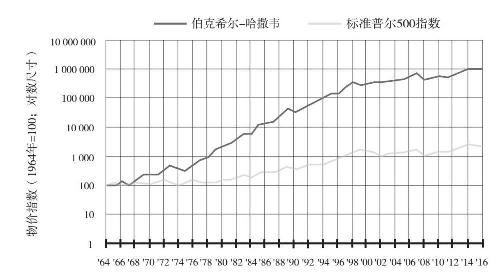

##### 图6.1 伯克希尔-哈撒韦公司1964—2016年的股票情况

现在我们来聚焦于2017年1月下旬随机抽取的一天（见图6.2）。上涨和下跌看起来非常剧烈并且令人担忧。可以想象在11：30左右处于最低点时，持股者会感觉到自己的损失是螺旋式上升的。

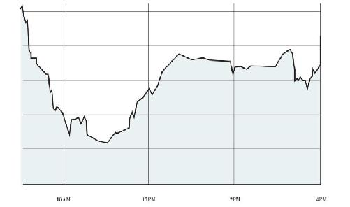

##### 图6.2 伯克希尔-哈撒韦公司2017年1月下旬某日的股票情况

如果我们研究了2008年9月—2009年3月银行业危机期间伯克希尔-哈撒韦公司股票的表现，那么你会发现它在大多数时候非常糟糕（见图6.3）。

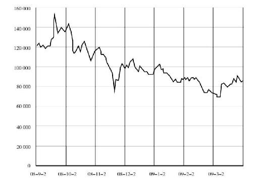

##### 图6.3 伯克希尔-哈撒韦公司在2008年9月—2009年3月期间的股票情况

然而，从图6.1的总体趋势中我们了解到，所有那些每分钟甚至每天的变化对投资的总体上升轨迹几乎没有影响。

可问题是，我们是自己生活中的股票行情观察者。幸福（无论我们如何对它进行定义）并不是通过注视股票行情指标，以及聚焦与每天甚至每时每刻的变化来衡量的。我们最好把幸福视为长期的持股。我们应该通过广角镜头来观察幸福，努力在我们的幸福股中寻求长期持续的上升趋势，使其表现类似于图6.1中的伯克希尔-哈撒韦公司。

心理时间旅行使这种视角成为可能。我们可以利用过去和未来的自己带我们离开当下，并在我们注视行情指标以及使用超大焦距镜头审视生活时给我们提醒。

在变焦镜头的放大倍率下观察这些瞬间的上涨和下跌时，我们的情绪反应同样也被放大了。就像上述雨中的爆胎，我们可能会把长期以来对幸福影响不大的事物视为具有重大影响的事。我们的决策变得具有反应性，专注于消除负面情绪或在面对现状的最新变化时保持积极情绪。我们可以看到这如何导致了自利性偏差：通过将坏结果归咎于运气来消除负面情绪，以及通过将好结果归功于自己来维持积极情绪。由瞬间情绪驱动的决策可能会成为一种自我实现的预言，会降低我们的决策质量，增加不良后果出现的机会，并使事态恶化。

## 嗯是的，但最近你给了我什么好处

盯着行情指标不仅放大了最近发生的事情，也扭曲了我们对近期事态的看法。要想了解看法失真的其他原因，赌场是个非常合适的选择。

想象一下你和朋友们一起去赌场玩21点。在前半个小时里，你进展顺利且赢了1 000美元。因为你和友人们都过得很愉快，所以你们继续玩。而在接下来的一个半小时里，你似乎连一手牌都赢不了。最后你输掉了赢来的1 000元，但整个晚上保持了收支平衡。你对这种情况有什么感想？

现在想象一下另一种场景，你在前半个小时内输掉了1 000美元并坚持继续玩下去，因为你的朋友们正玩得开心。但在接下来的一个半小时里，你通过接连获胜弥补了先前的损失，最终以不赚不赔而收场。你对这种情况又有什么感想？

我猜你会因为一开始赢钱但最后不赔不赚而感到失望和郁闷，而在第二种情况下，你可能会高兴到想请桌上的每个人喝一杯。虽然通过不同的方式得到了相同的结果——在两种情况下你离开牌局时都没有赢也没有输钱——但在一种情况下你很失望，另一种情况却让你很开心。

就像广告片里经常会说的：“但是，等等！还没完呢！”

我们区分结果的方式是一种路径依赖。我们最终到达何处以及如何到达那里并不重要。即便我们的总体表现不错，最近发生的事件仍然会对我们的情绪产生强烈的影响。这就是为什么我们赢得100美元却感到沮丧，输掉100元却感到开心。变焦镜头不仅会放大，还会扭曲图像。这不仅适用于打牌，同样也适用于投资决策、人际关系甚至是路边爆胎的情况。如果我们在上周获得了职位晋升而在今天遇上了爆胎，我们会诅咒生活，抱怨不幸。我们的感受并不是对事情总体进展而产生的反应。我们会因为一项投资的收支平衡（或赚钱）而感到失望，因为它曾经有过更高的价值。在人际关系中，即使微不足道的分歧在争执的时候也会显得十分严重。所有这些情况（以及无数其他情况）的问题在于，我们当下的情绪会影响我们的决策质量，而且我们尤其愿意在情绪不稳定的时候做出决策。

想象一下，如果这次打牌发生在一年前又会如何。对于较长时间以前出现的某个结果，由于情绪早已恢复理智，你的态度很可能会出现反转。现在的你会因为当时赢得的100美元而非输掉的100美元而高兴。一旦我们通过时间旅行的方式暂时脱离现在，我们就可以站在全局的角度来审视这些局部问题，而不会被行情指标显示的涨跌扭曲了思维。

这也是扑克牌桌上的一个常态挑战。虽然移动记分牌能够提醒玩家所有决定都会产生相应的结果，但它的缺点就像行情指标一样，反映了最近发生的形势变化。这给玩家们制造了一种关注计分的风险，会导致他们根据瞬间的变化做出片面的非理性决策。这是扑克玩家们经常会考虑到的一个问题。

## 倾斜

冲浪者有20多个术语来描述不同类型的波浪。原因在于波浪的类型、碎波方式、方向以及底部深度等因素都为冲浪者带来不同的挑战。还有被称为“全闭”（涌起全程呈破碎状态的一整道波浪）、“双击”（由两层波浪相遇形成的波浪）和“重组”（碎波、平息然后再次碎波的波浪）的波浪。非冲浪者将所有这些情况都称为“波浪”。在极少数情况下，当我们这些非冲浪者需要更具体的描述时，只需添加许多额外的字词。这些额外的字词不需要费工夫专门去记忆或了解，因为很少会用到，也许永远不会再次用到。但是对于参与运动的专业人士来说，能够用一个单词来传达外行人需要用冗长的叙述才能表达的复杂概念是值得的。专业人士使用的一些细致、精确的词汇就是行话。这是为什么木匠把至少十几个名字用于不同类型的钉子，而在神经肿瘤领域中存在着超过120种大脑和中枢神经系统肿瘤类型。

由于扑克玩家总是需要努力保持全面客观的态度来对待瞬间得失，他们有各种各样的行话来表达下面这一概念：“坏结果会使你的情绪产生波动，从而影响下一步的决策制定，让你会做出再次导致坏结果的非理性决定，从而进一步对你的决策制定产生负面影响，如此循环。”最常见的一种概念叫作倾斜（tilt）。倾斜是扑克玩家最大的敌人，使用这个词会立即让其他玩家明白，你因为受到坏结果的影响而做出了情绪化的决策。<sup>[6]</sup>如果你夸大近期事件的严重性并且对其做出激烈的反应，这就说明你正在倾斜。

倾斜的概念来自传统的弹球机。为了防止玩家通过掀起游戏桌来改变球的运行轨迹而损坏机器，制造商在其内部安置了传感器，当球桌受到猛烈晃动时机器会自动停止运行。击球手柄将停止工作，游戏灯也会熄灭，倾斜一词会在桌面上的许多地方闪现。这一说法之所以能够适用于我们的决策过程，是因为在倾斜的瞬间，我们大脑内部的情况就像一台被倾斜了的弹球机。当大脑的情绪中心开始鸣叫时，边缘系统（特别是杏仁核）就会关闭前额皮层。我们开启了警示灯……并关闭了自己的认知控制中心。

倾斜带有情绪和生理迹象。打牌时，你也能听到一个倾斜的玩家在说话。每隔几手牌，你都会听到高分贝的声音伴随着一种难以置信的语气：“不是跟我开玩笑吧？又来一次（这种牌）？”或“真不知道为什么我还在打牌。还不如直接把钱送给对手”（想象一下愤怒的语调加以大量的咒骂）。除了这些言语线索外，还有生理方面的迹象。倾斜的时候，我们可以感觉到自己的脸发热，心跳加速，而且呼吸急促。

当然，倾斜不仅仅限于扑克，任何形式的结果都有可能引起情绪反应。我们可能会在与伙伴的分歧中做出被动的情绪化决定，或者在经历了糟糕的餐厅服务、工作场所的闲言碎语、成交的订单被取消或者提议被否决时，我们也会变得不理智。我们在个人生活和职业生涯中都有过这样的经历：由于瞬间的情绪反应而将事情的严重性无限放大。

通过提前认识这些言语和生理信号，我们才能有的放矢地培养一些习惯来应对倾斜的情况。当我们感觉到倾斜的迹象时，无论是在与配偶或孩子们的争执时、工作中遇到令人烦恼的事情时，还是在扑克牌桌上失利时，我们都可以预演自己暂时离开现场的情景。我们可以尝试独处，冷静下来之后我们应该认识到自己不应该在处于倾斜状态时做出任何决策。像“深呼吸十次”和“要不明天再做决定？”就是规劝人们要避免在倾斜时做出决定的格言。我们可以尝试10-10-10的方法或问自己类似“过去发生了什么事情给了我这种感觉？”或“它是否会有助于我在这种（倾斜）状态下的决策制定？”的问题。我们还可以通过问自己这将如何或者是否会对我们的长期幸福产生真正的影响来获得理性的观点。

如果你加入了某个求真团体，该团体可以准备一些有针对性的问题来用于发现倾斜，并减少我们在倾斜时执行的决策数量。我们可以在互相评估决策时对关注行情指标的行为保持警惕，可以采用最明显的一个问题：“你认为自己（当时）是否在倾斜？”接着我们可以提出关于时间旅行的问题，例如：“从长远来看，你认为这真的会产生什么影响吗？”如果我们将倾斜的概念及其对决策质量的负面影响作为讨论的一部分，就会围绕倾斜问题产生一种对团体的责任性。忽视情绪化决策制定的信号可能会使我们因此向团体做出解释。反过来，这将使我们从团体中得到积极的强化，以识别倾斜的迹象并避免在该状态下做出决策。这样还有助于培养良好的思维习惯，让我们可以充当自己的决策伙伴来操作这些程序。

在我的扑克生涯刚开始时，我听到业内一些传奇人物说过这么一句话：“这只是一场长时间的扑克游戏。”这句话可以用来提醒我们要从长远的角度看待事物，特别是当某件大事刚刚发生、上一手牌输得很惨或遭遇了爆胎的时候。一旦学会如何召集过去和未来版本的我们来提醒自己，我们就能够以理性的态度对待最近发生的变化和波动。从长远的角度看待问题可以培养更加理性的思维方式。

## 尤利西斯合约：利用时间旅行来预先承诺

最著名的古代旅行家，荷马史诗中的英雄奥德修斯也是一位心理时间旅行者。塞壬岛（Sirens）的故事是有关他返回家乡的传奇航海经历之一。经过塞壬岛附近的水手们都被塞壬的歌声吸引，以至于会不由自主地驶向海岛并撞上岛周围的岩石滩而死。鉴于所有听过歌声的水手都难逃厄运，在船接近岛屿时，奥德修斯让他的船员们把他的手绑在桅杆上并用蜂蜡塞住他们自己的耳朵。这样一来，水手们可以安全地行船而免于受到歌声的影响，同时奥德修斯也可以在不危及船只的情况下欣赏塞壬的歌声。

这个计划完美无缺。这种行为——利用过去的我们阻止现在的我们做出蠢事——被称为尤利西斯合约（Ulysses contract）。（荷马著作的大多数翻译都使用英雄的古希腊名字奥德修斯，时间旅行策略使用的是英雄的古罗马名字尤利西斯。）

这是过去的你、现在的你和未来的你之间的完美互动。尤利西斯意识到未来的自己（以及他的船员）会被塞壬吸引并将船只驶向岩石滩。因此，他让船员们用蜡塞住各自的耳朵并将他本人的双手绑在桅杆上，如此切实有效地预防了未来的自己会做出糟糕行为的可能性。体现这种合约最简单的例子之一是当你去酒吧时使用了拼车服务。过去的你因为预计到将来的你可能会在酒后认为自己完全可以开车，所以事先捆住了你的双手，取走了车钥匙。

尤利西斯合约的大多数事例都与原文讲述的一样，都涉及了提升针对非理性行为的约束。但是，这些预先承诺的合约同样也可以被设计为降低约束理性行为的手段。如果想要保持健康饮食，我们有时候可能会发现自己的非理性决策冲动。例如，我们约了朋友晚些时候见面一同去逛商场，但我们却利用之前的空闲时间在美食广场里溜达了几个小时。在提升约束力的尤利西斯合约下，我们根本不会去商场或者时间预留得非常紧凑，以至于我们可以用来完成预期目的时间非常有限。而在降低约束力的合约中，我们会通过预先承诺把健康零食装进包里，这样可以增加做出更好决策的概率，因为我们已经显著节省了想吃到健康零食所需要付出的努力。

尤利西斯合约可以对我们的行为进行不同程度的约束，从防止肉体上的决策执行到除合约本身无其他约束情况下的提前行动。无论约束程度如何，这些预先承诺合约都会触发一种决策中断。在我们想要违背合约、摆脱约束力时，我们很有可能会停下来想一想。

若我们的肉体被禁止决策，就无法采取任何非理性的冲动行为，从这种意义上来说，我们被中断了，在这种禁止的情况下我们没有任何选项。这是一种野蛮的时间旅行方式。过去的尤利西斯通过禁止肉体行动中断了现在的尤利西斯的决策。

在大多数情况下，你无法做出一个100%不受干扰的预先承诺。措施的约束力未必很大，却足以导致决策中断，这可能会促使我们进行一些必要的时间旅行以减少情绪作用，并在决策中鼓励全局思维和理性思考。参加和解谈判的律师可以与客户或团队中的其他律师一同就客户在和解中可以接受的最低金额（或同意支付的最高金额）进行预先确认。购房者可能会看中某处房屋后变得感情用事，所以他们应该提前确定预算。一旦决定要购买某处房屋，他们应该提前确定他们愿意支付的最高金额，这样他们就不会在竞标时措手不及。

扔掉家里所有的垃圾食品会使我们无法在黑夜里惬意地、不假思索地吞下一品脱（约0.57升）的冰激凌。但只要有一辆汽车或附近有送餐服务，我们仍然可以吃到想吃的东西，只是需要花费更多的精力而已。在餐厅里也有类似的情形，即使要求服务员不要把面包篮放在餐桌上，很显然我们一样可以吃到面包，但必须再次向服务员提出要求。事实上，如果在听到塞壬的歌声后忍不住要让人给自己松绑，即使是尤利西斯那样的人物也必须指望他的船员能够忽视他。

尤利西斯合约可以通过多种方式来帮助我们成为更加理性的投资者。将收入的一部分设置为自动转账到养老金账户就是一个尤利西斯合约。虽然我们可以改变这种分配方式，但最初的安排让我们的目标设定——系统2的自己可以预先确认这种长期看来对我们最有利的安排。如果想要改变分配方式，我们必须采取一些具体步骤来制造一个决策中断。

投资顾问会采用这种方式与客户讨论他们的目标。他们会提前与客户确认在何种情况下应该针对特定股票进行买入、卖出、持有或压低头寸。如果客户稍后想要做出情绪化的决定（如涉及投资价值的突然上升或下降），顾问就可以提醒客户之前进行的讨论和达成的一致意见。

在所有这些情况下，预先承诺或预先决策并没有完全束缚我们的行动力。要在肉体上执行一项情绪化的、被动反应的非理性决策仍然是可能的（尽管在不同程度上更加困难）。然而，预先承诺在行动之前提供了一个停止思考的时刻，触发了潜在的审慎思维。这样能够阻止每一次情绪化的非理性决策吗？不能。我们有时仍会以条件反射或不假思索的方式做出决定吗？当然会。但这种情况的发生概率会显著降低。

## 决策脏话罐

我们都知道脏话罐的概念：谁说了脏话，就往罐子里丢一美元以示惩罚。这种做法背后的考虑是，它会让人们注意不要说脏话以及减少说脏话的频率。决策脏话罐是一种简单的预先承诺合约，我们可以将其应用于本书的许多关键概念中。决策脏话罐可用于辨别一些表明自己正在偏离求真目标的语言和思维模式，当我们发现自己使用某些词语或屈服于我们试图避免的一些表现为非理性信号的思维模式时，就会产生一个停下来思考的时刻。你可以将此视为实施问责制的一种方式。

我们以确立信念和区分结果的方式讨论了几种非理性的模式。通过这些了解，我们可以对一些表明自己可能处于不理性状态的语言和想法保持警惕。这些警示信号的内容将仅仅适用于你个人（或你的家人、朋友或企业），但下列可能会触发决策中断的各种例子可作为统一参考。

> 肯定性错觉的迹象：“我知道”“我确定”“我早就知道”“它总是以这种方式发生”“我对此非常确信”“你完全搞错了”“你完全不明白你自己在说什么”“这绝对不可能是真的”“绝无丝毫可能”“100%”或同等表达，以及其他表明我们夸大了肯定性的言语。其中还包括将事物陈述为绝对的说法，如“最佳”或“最差”，“总是”或“永不”。

> 过度自信：与上述肯定性错觉类似的说法。

> 不理性的结果区分：“我无法相信我会如此不幸”，或者如果我们有一些将好结果归功于自己的默认说法，这一表达就会反过来，比如“我发挥了我的巅峰水平”或“我的计划完美无瑕”。这些结论不仅包括运气、技巧、指责或名声，还包含非理性地区分他人结果的同等说法，例如“他们完全是罪有应得”“他们是自找的”“为什么他们总是如此幸运”。

> 任何仅仅为了发泄情绪的呻吟或对糟糕运气进行抱怨的行为，除了用来获得同情之外没有任何积极意义（我们在求真团体中明确表示自己是在利用暂时休息的机会来宣泄的情况除外）。

> 广义地对他人进行描述意味着忽视他们的想法：对他人的侮辱和贬义的描述有“白痴”和扑克中的“驴子”（donkey），或者任何将他人称为以“另一个典型的_____”开头的言语（如同大卫·莱特曼对劳伦·康拉德说的一样，他把周围的人当作白痴一样忽略了，直到有一天他开始使用审慎思维进行思考才想到这个问题：“其他人都是白痴的概率有多大？”）。

> 其他违反默顿的普遍性规范的行为，如因为不认可信使而否定信息本身。任何关于某人的片面说法，特别是当我们把对某种想法的评估等同于对想法表达者的全面个性或智力评估时，例如“枪痴”“流血的心脏”“东海岸”“圣经地带”“加州价值观”——政治或社会问题。同样需要对相反的情况加以提防：因为对信使的认可而接受信息，或在发现自己的想法被确认后立即对信息来源加以肯定。

> 我们聚焦于某个时刻，将时间范围刻意夸张放大的信号：“最糟糕的一天”和“地狱般的一天”。

> 明确表明动机推理以及无充分依据地接受或排斥信息的表述，如“传统智慧”、“如果你问任何人”或“你能证明这不是真的吗”。同样，留意那些表明你参与了回声室的表述，如“每一个人都赞同我的观点”。

> “错误”一词应该享有自己的脏话罐。默顿式规范的、有条理的怀疑性在探索性讨论“错误”一词时没留有任何余地。“错误”是一个结论，而不是阐述。而且它并不是一个特别准确的结论，因为我们知道，几乎没有任何事物的正确性或错误性是100%或0。任何否认不确定性存在的言论或想法都意味着我们正在制定一项偏差严重的决策。

> 缺乏自我同情心：如果我们想要进行自我批评，那么重点应是从经验中学习以及如何校准未来的决策。这类的信号包括“我对事物联系的判断能力太差”、“我应该知道的”或“我怎么会这么笨”。

> 一些我们对自己分享的故事进行过分的编辑信号。尤其是在求真团体中，我们是否偏离了事实的分享以强调我们的修改版本？即使在团体之外，除了我们纯粹为了娱乐而分享故事外，是否会确保听众同意我们的观点？一般来说，我们是否违反了默顿的共有性规范？

> 使听众感受到利益冲突、征求建议时加入我们自己的结论和信念，以及在听取意见之前将结果告知听众。

> 阻止他人和他人意见参与的言语，例如确定性的表述以及从即兴表演中学到的用以缓和异议的初步措辞——“是的，而且……”这包括从别人那里获得意见或信息，并回应以“不”或“但是……”。

以上绝不是一份完整的清单，但它提供了各种应该引起我们警惕的表述和想法类型。

一旦意识到自己应该对一些特定的言语和想法加以提防，当我们发现自己在进行这类表达或思考时就是违反了合约，违背了寻求真理的承诺。这些言语是我们屈服于偏见的信号。因为如果我们发现自己在进行这类表达或思考时不加以约束，这就会触发一个反思的时刻来打断我们。这一时刻的突然出现可以提醒我们为什么要煞费苦心地罗列一份表明潜在决策陷阱迹象的清单。

脏话罐是尤利西斯合约的一个简单例子：我们在未来的决策制定中考虑到危险，并为此设计一个行动计划，或者至少承诺自己会花一点时间来确认我们正在偏离求真务实。更好地预先承诺合约源于我们对未来的更好预期、我们希望避免的决策类型，以及我们想要提倡的决策，这需要经过深思熟虑的侦查。

## 侦察：规划未来

霸王行动（Operation Overlord）是盟军部队从诺曼底出发夺回被德国侵占的法国的一次军事行动，这是世界军事历史上最大的海上入侵行动，它涉及规模空前的战略部署和后勤管理。如果部队行动在一开始就被恶劣天气耽搁了怎么办？如果因为地形影响空降部队无法进行无线电通信怎么办？如果大量的伞兵在降落后偏离目标地点怎么办？如果海潮干扰了部队从海滩登陆怎么办？如果从不同海滩登陆的部队无法会师怎么办？其中牵扯到无数环节，任何一处都有可能出错，成千上万的生命经受着死亡的威胁，这就是战争的潜在后果。

以上提及的所有方面的确都出现了问题，而且在登陆日（D-Day）及其后立即遇到了许多其他挑战。然而，由于盟军的统帅们预先为尽可能多的潜在场景进行了大量的准备，诺曼底登陆仍然取得了成功。自从马匹被应用于战争，情报侦察就成为预先军事计划的重要组成部分。当然，现代军队早已从派遣骑兵进行情报刺探发展到利用飞机、无人机、卫星和其他高科技设备来收集战争情报了。

捕获并击毙奥萨马·本·拉登的海豹突击队不会在对墙内状况一无所知的情况下贸然进入院落。院子里都有什么建筑？其布局和作用分别是什么？如果选择在不同的天气状况下或同一天的不同时间内进行突袭会有什么不同？哪些人会有可能在场，这些人会对突击行动构成什么威胁？如果本·拉登本人不在院落内他们会怎么做？根据对以上情况（当然还有其他许多情况）的了解，突击队试图达到何种目的？正如突击队员们需要依靠情报侦察来计划行动一样，在对任何决策可能会导致的结果范围以及可能会发生的概率事件进行细致的研究之前，我们不应该对自己的未来进行规划。

为了做出更好的决策，我们需要对未来进行侦察。如果某个决策是基于我们的信念对一个特定的未来进行下注，那么在下注之前，我们应该仔细考虑和预期未来的具体情形。任何决定都可能会导致一系列不同的结果。

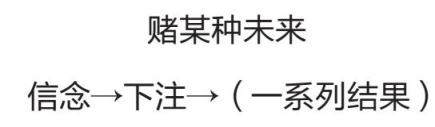

考虑这些结果中包含了哪些未来（我们用一种新的方式来体现可能出现的结果）有助于我们弄清楚要做出什么决策。

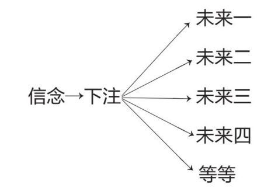

先弄清楚可能性，然后再做尝试。首先，我们想象一下潜在未来的范围。这也被称为情景规划。从获得最佳战略应用的角度对数据进行编译和解读的内特·西尔弗经常采用情景规划方法。他有时会采用对那些具备数据支持的所有情景进行讨论的方法，而不是使用数据来得出特定的结论。他在2017年2月初对情景规划的优点进行了描述：“当面临高度不确定的情况时，军事单位和大型企业有时会采用一种叫作情景规划的实践。其目标是考虑未来将会以何种方式展现各种可能性以帮助指导长期规划和准备。”

在尽可能多地判断可能出现的结果之后，我们需要努力地猜测每一项未来事件的发生概率。当我向企业提供与建立决策树和确定未来事件的发生概率相关的咨询时，人们经常因为必须对未来事件的发生概率进行猜测而产生抵触，这主要是因为他们觉得自己无法确定任何情景的发生概率。但这就是我让他们尝试猜测之所以重要的原因。

我们进行侦察是因为我们不确定。我们不（也许无法）知道事情发展成为某种精确结果的概率有多大。重要的不是从完美的角度来接近我们对未来的预测，而是确认我们每次做出决策都是在预测未来，明确这一点会对我们更有利。我们对猜测结果的担心本身就是一个猜测的过程。鉴于我们可以获得的各种选项，我们猜测决策执行最有可能获得好的结果。至少通过尝试对概率进行分配，我们自然会偏离非黑即白的极端肯定思维。与放弃任何尝试的态度相比较，任何让我们得以摆脱这些极端情况的做法都将是更加理性的评估。即使我们的评估结果范围很广，比如特定情景的发生概率在20%~80%之间，这仍然要强于放弃猜测。

这种对未来进行侦察的做法是经验丰富的扑克玩家们非常熟悉的手段。在下注之前，扑克玩家会考虑每个对手的可能反应（弃牌、跟注、加注），以及每种反应的可能性和可取性，（如果部分或全部对手不选择弃牌）他们还会考虑自己将如何做出回应。即使你对扑克知之甚少，也很容易理解为什么玩家们应该在下注之前考虑这些事情。越老练的玩家越是会进行长远的决策规划。在决定下注之前，老练的玩家就会预测自己将要如何应对各种局面，以及此刻采取的行动会如何影响自己在这手牌中将要做出的决策。最优秀的玩家们会跳出当前一手牌来考虑问题：此刻的行为会如何影响自己以及对手们在下一手牌中的决策？扑克玩家确实生活在一个这样的概率世界中：“未来有哪些可能性？那些可能性的发生概率有多大？”他们已经非常习惯于面对自己无法肯定的事实，因为他们无法看到对手玩家们的牌面。

大多数战略性思考都是如此。无论是涉及销售策略、商业策略还是法庭策略，最优秀的战略家都会更加全面地考虑各种可能性，预测和分析每一种情况下的战略反应，并以这种方式深入决策树。

这种情景规划是我们可以自己进行的一种心理时间旅行。如果我们将其作为情景规划团体活动的一部分，它的作用会更加显著，特别是在一些对异议和不同观点持开放态度的团体中。不同的观点允许我们深入决策树中去识别更多种类的场景，并且对它们的概率进行更好的预估。事实上，如果团体中有两名成员对某一结果的发生概率存在着很大的估计偏差，那么这正是让他们调换立场为对方观点进行辩护的好时机。一般来说，最终结果位于两种对立观点中间的某个地方，而两名成员都会以调整各自的立场而结束沟通。但有时一方成员会想到另一方没有想到的关键影响因素，该信息只有在能够容纳异议的情况下才会被发现。

除了提高决策质量，对各种未来可能性进行侦查还有许多额外的益处。首先，情景规划提醒着我们未来在本质上是不确定的。通过在决策过程中对这一点进行明确，我们对世界的看法会变得更加客观。其次，这会为应对可能由我们的初步决策而产生的不同结果做出更好的准备。我们可以预测积极或消极的情况并制定应对战略，而不是仅仅被动地做出反应。能够应对不断变化的未来是一件好事，对变化的未来感到措手不及绝非好事。情景规划使我们更加敏捷灵活，因为我们已经为应对各种未来可能出现的情况进行了充分考虑并做好了相应准备。如果我们通过侦察发现自己容易受到非理性的影响，我们可以尝试采用尤利西斯合约来约束我们的行动力。第三，对结果的范围进行预测也会使我们在某些未来情况发生时不会感到毫无意义的遗憾（或过度的兴奋）。最后，通过对未来的可能性和结果发生的概率进行预测，我们就不太可能成为以结果为导向或事后偏见的牺牲品（这些偏见使我们对没有发生的未来加以掩饰，并将发生的结果视为不可避免），因为我们已经对可能发生的所有情况进行了分析。

## 情景规划的实践

几年前，我为一家名叫“课外全明星”的全国性非营利组织提供咨询服务，与他们进行协作，将情景规划纳入组织预算。<sup>[7]</sup>由阿诺德·施瓦辛格（Arnold Schwarzenegger）于1992年创立的“课外全明星”在美国的18个城市为70 000多名低收入家庭的学生提供日均3小时的课外全面教育计划。该机构在很大程度上依赖于政府拨款以维持运营，而且鉴于拨款审批过程中的不确定性，他们当时正在艰难地进行预算规划。为了帮助他们进行规划，我要求他们列出所有的拨款申请以及每笔拨款的价值。他们向我提供了所有未付拨款的申请表以及申请资金数额。我告诉他们，在他们提供的信息中我没有看到每笔拨款的价值，他们却让我看申请数额那一栏的内容。那时我才意识到，我们对于如何判定价值有着不同的理解。误解来自每笔拨款的预期价值与他们实际可能获得的拨款数额之间的认知脱节。<sup>[8]</sup>

确定每一项拨款的预期价值涉及一种简单形式的情景规划：想象一下申请拨款可能会出现的两种结果（批准或拒绝），以及每一种结果的可能性。例如，如果他们申请一笔100 000美元经费的成功概率是25%，那么该项拨款的预期价值应为25 000美元（100 000美元×0.25）。如果他们只有四分之一的概率可以获得该数额，那么它的价值就不是100 000美元，而是100 000美元的四分之一。如果申请200 000美元的成功概率为10%，那么预期价值就是20 000美元；如果申请50 000美元的成功概率为70%，则预期价值为35 000美元。如果没有经过这种概率性的思考，就无法确定一笔拨款的价值——这将导致人们错误地认为（以上述内容为例）200 000美元的数额最大，而实际上最有价值的却是50 000美元的拨款。“课外全明星”组织意识到不确定性造成了麻烦（以至于他们在做预算时有被奴役的感觉），但他们没有将不确定性纳入规划或资源分配的过程中。他们完全是在依靠直觉盲目行事。

在我与他们的全国办事处合作之后，“课外全明星”将预估获得每一项拨款的概率纳入了预算规划。他们从情景规划中获得了立竿见影的好处。

> 他们创建了一个更高效，更多产的工作栈。在进行这项实践之前，他们自然会优先考虑寻求更高金额的申请并首先执行这些操作。他们将更多高级职员投入其中，并且很有可能会聘请外部人员来进行拨款申请文书的编撰。通过考虑获得每一笔拨款的成功概率，他们现在能够根据拨款对于组织的实际价值，在决策制定过程中更加合理地对其进行安排。此后，不再仅仅是一些预期数额较大的申请，那些具有较高价值的经费也得到了很高的重视。

> 他们可以更好地结合实际情况进行预算。他们在预估可以获得的资金数额方面更有信心。

> 由于确定预期价值需要对获得拨款的概率进行估算，他们越来越注重提高估算的准确性。这促使他们与审批机构接触以确认申请结果。之前在审批未能通过后他们也曾与审批机构联系跟进。因为专注于概率的核验和校准，他们将这种做法扩展到了已经获批的拨款上。总体而言，他们在结果后期评估中侧重于了解哪些做法有效，哪些无效，哪些结果是因为运气以及如何才能做得更好，同时也侧重于提高他们的概率估计和拨款申请质量。

> 他们可以设法提升获得拨款的概率以及致力于相关实践。由于事先对能否成功获得拨款进行了分析和考虑，他们不太可能成为事后偏见的牺牲品。

> 由于事先对能否成功获得拨款的决策过程进行了评估，他们不太可能成为以结果为导向的牺牲品。

> 最后，由于“课外全明星”通过将场景规划纳入预算和拨款申请而获得了好处，他们将此类场景规划的实施扩展至其他部门，使之成为其决策文化的组成部分。

拨款预期与销售预期类似，这种流程可以在任何销售团队中实施。分配成交或不成交的概率可以使公司更好地确定销售优先级、规划预算和分配资源、对预测的准确性进行评估和调整，并保护自己免受以结果为导向和事后偏见的危害。

当可能的未来数量增加并且/或者当我们进一步深入决策树时，会出现一个版本更加复杂的情景规划，来应对我们下一步如何对事情的结果做出回应以及该决策将会产生哪些结果等问题。

如果卡罗尔下令冲锋，会导致以下可能的结果：（1）触地得分（立即获胜）；（2）丢球-漏接（立即失败）；（3）未达到球门线；（4）进攻犯规；（5）防守犯规。结果（3）~（5）又可细分为其他情况。显然，最可能的失败情况是跑垒员在到达终点区域之前被拦截。海鹰队可以在最后时刻要求一次暂停，但如果他们再次控球冲锋未能得分，比赛就会以他们的失败告终。

如果卡罗尔示意抛传，可能会出现的结果有：（1）触地得分（立即获胜）；（2）丢球-截获（立即失败）；（3）抛传不完整；（4）遭遇抱摔；（5）进攻犯规；（6）防守犯规。同样，前两种结果基本上结束了游戏，而其他结果又将引起进一步的战术口令并导致其他结果。

抛传和冲锋之间的主要区别在于，卡罗尔的抛传决策可以给海鹰队制造三次战术机会，而如果下令冲锋，则只有两次机会。一次失败的冲锋导致海鹰队必须使用他们最后一次的暂停机会来停止计时，以便他们可以进行下一次进攻。一个不完整的抛传可以给海鹰队一次暂停机会连同另外两次进攻机会。而遭遇截获则会断绝第二次或第三次进攻的可能性，这种情况在场上的概率仅有2%~3%，因此卡罗尔做出了选择三次而非两次得分机会的决策是完全合乎情理的。（由于进攻中的漏接导致的失球概率为1%~2%。）<sup>[9]</sup>

需要注意的是，如果没有这种对未来可能性的侦察，额外进攻机会的选项就不会显现。即使在结果发生以后，在有足够的时间来分析的情况下，也很少有评论员看到该决策的优势。

重要的是，当我们对所有这些未来进行侦察并根据不同未来的可能性和可取性进行决策时，我们会获得更好的结果。“课外全明星”无法保证它的每一项拨款申请都会获得批准，但它可以通过良好的方法在优先处理部分申请以及在所有申请的预期价值方面做出更好的决策。尽管遭受了强烈指责，但我还是认为皮特·卡罗尔应该会在下令威尔逊抛传的决策上感到心安理得。

对未来的可能性进行侦察可以显著提高决策质量并降低对结果的被动反应。我们已经谈到了对未来的样子进行设想。但事实证明，更好的决策树和更有效的情景规划都来自逆向思维而非前瞻思维。

## 反向回顾：从一个积极的未来开始逆向思考

对未来进行想象的方法并非只有一种。中国有一句谚语叫作“千里之行，始于足下”。事实证明，如果我们要计划如何完成1 000英里（约1 609千米）的徒步旅行，最好的做法是想象自己从目的地的位置来回顾我们是如何一步步地走到终点的。就预见性思维而言，站在终点向后看比从起点向前看更加有效。

当我们从现在展现未来时，得到的扭曲观点类似于《纽约客》杂志曾经在其封面上嘲笑过的曼哈顿居民那种陈旧的世界观。杂志封面是以一个纽约人的视角绘制的一幅地图，该地图的一半为纽约都市街区。虽然你可以看到第九大道上的所有建筑物，甚至是车辆和行人，但哈德孙河连同新泽西州一起却仅显示为狭窄的横向条状物。整个美国占据的空间与第九和第十大道之间的距离相同。在太平洋条状物之外有三小块位置，分别被标注为“中国”、“日本”和“俄罗斯”。

在预测未来时，我们会面临类似的失真的风险。从我们所处的位置来看，眼前和即将要发生的事会显得更为重要。除此之外的任何事情都会失去焦点。

想象未来与回忆过去需要调动相同的脑神经通路。事实证明，记住未来是一种更好的计划方式。以目前的观点为依据，我们很难看到下一步之后的情况，因此我们最终针对当前遇到的问题进行了过度的规划。这种方法隐含的假设是条件将保持不变、事实不会改变而且范式也将保持稳定。世界变化过于迅速，所以不能假设该方法在通常情况下都是有效的。塞缪尔·阿贝斯曼的《事实的半衰期》用一整本书的篇幅讨论了将未来想象成与现在一样的危险。

正如优秀的扑克玩家和象棋选手（以及任何领域的专家）可以比其他人更好地对未来做出进一步的规划，当我们能够更加生动地想象未来而不受现状扭曲时，我们的决策质量就能够得到改善。通过从目标开始逆向思考，由于是从终点入手，我们可以更加深入地对决策树进行规划。

研究表明，我们在确定目标并开始逆向思考以试图“回忆”起我们是如何到达终点时表现得更好。决策科学家加里·克莱恩（Gary Klein）在《哈佛商业评论》的一篇文章中总结了由黛博拉·米切尔（Deborah Mitchell）、J. 爱德华·拉索（J. Edward Russo）和南希·彭宁顿（Nancy Pennington）在1989年进行的实验的结果。他们“发现预期的后见之明——想象事件已经发生——会使人们在准确识别导致未来结果方面的能力提升30%”。

庞大的城市规划项目需要大量的资金、材料、责任以及从未来目标开始逆向工作的愿景。例如，当弗雷德里克·劳·奥姆斯特德（Frederick Law Olmsted）开始设计中央公园时就设想到，公园的魅力以及人们从中获得的乐趣都需要经过数十年时间的景观变化和成熟之后才能得到完整的体现。在1858年公园向公众开放时，人们穿过公园会经过很多荒芜的土地。即使到了1873年，建筑工程基本完成时，公园内仍有大量未长成型的植物。树木、灌木和其他植物显然是近些年才移植过去的。当时的那些游客一定不会认出今天的中央公园，但是奥姆斯特德会认得出，因为他的设计构想始于今日的结果。

通过从预期目标进行逆向思考来规划未来的形式被称为反向回顾。在反向回顾中，我们想象自己已经获得了某种积极成果，手持一份报纸，大标题显示为“我们成功了！”然后我们再思考目标实现的过程。

假设一家企业打算制订一项3年战略计划，将市场份额从5%提高到10%。参与进行计划制订的每个人都想象自己拿着一份头条标题为“X公司在过去3年中市场份额翻倍”的报纸。然后团队负责人询问，是什么原因使他们实现了目标，过程中发生了哪些事件，做出了哪些决策，哪些有利条件促成了企业获得如此规模的市场份额。这种实践不仅使公司能够更好地确定为实现目标而需要实施的策略、战术和行动，还有助于发现什么时候需要对目标进行调整。反向回顾使我们可以辨别那些实现目标所必须发生的低概率事件，这可以促使战略发展以增加这类事件的发生概率或者有助于决策者认识到目标过于远大。该公司还可以对通过反向回顾来制订的计划做出预先承诺，包括如何应对可能会干扰目标实现的问题，以及在未来应如何辨别重新评估计划的转折点。

在接手新案件后制定审判策略时，审判律师可以设想一下庭审获胜后的报纸头条。庭审过程中有哪些有利于该律师的裁决？最有利的证词是如何发挥作用的？法官允许或否决什么样的证据？陪审团针对哪些问题做出了回应？

如果我们的目标是在6个月内减掉20磅（约9千克），那么，可以通过设想自己已经在预定时间内完成了减肥目标来计划如何实现这一目标。为了减肥我们付出了哪些努力？我们是如何避免食用垃圾食品的？我们是如何增加运动量的？我们是如何恪守养生之道的？

设想一个成功的未来并从那里进行反向回顾是一项有用的时间旅行实践，有助于我们确定实现目标所必需的步骤。如果我们为自己设想一个不乐观的未来，逆向思考将会产生更大的作用。

## 预先检查：从一个负面的未来开始逆向思考

如果你对医学名词有所了解，或者喜爱观看法医及犯罪类剧集，那你应该会对一个名词感到熟悉——验尸（postmortem）：法医通过检验尸身来确定死因的方法。而事前验尸或预先检查（premortem）是对一些糟糕事件进行的调查，区别是这种调查是在事件发生之前进行的。我们都希望对未来持有乐观的态度。我们通常偏向于高估好事发生的概率。通过玫瑰色眼镜（指乐观态度）来看待世界给人自然且良好的感觉，但是稍许的反对意见对于决策制定也是非常有益的。预先检查是对我们的积极态度进行的立即检验，以及我们对自己未能实现目标的设想。

反向回顾和预先检查互为补充。反向回顾设想一个积极的未来，预先检查假定一个消极的未来。如果没有同时表示正面空间和负面空间，我们就无法创建完整的画面。反向回顾揭示了积极空间，预先检查揭示了消极空间。反向回顾是啦啦队队长，预先检查是观众中的起哄者。

设想一个写着“我们失败了”的标题会促使我们思考一些可能会出错的方面，这会有助于我们在自己（乐观的、团队合作的）的决策中提防这些问题。如果那家计划在3年内市场份额翻倍的公司见报的头条标题为“公司未能实现提升市场份额目标，增长再次停滞”，那么规划团队的成员们就可以设想到一系列导致失败的原因：新产品的延迟上市、关键管理（或销售、市场、技术）人员的流失、竞争对手发布新产品、不利的经济发展环境、导致客户终止产品需求的模式转变，或依靠未上市或未投入使用的替代品等。

正在审理案件的律师认为有利的证据遭到否定而尚未呈堂的证据可能对案件极为不利，同时描绘了无情的法官连同对主要证人无好感或不信任的陪审团。

如果我们设定了一个减肥目标并制订计划来实现该目标，预先检查的方法可以揭示这样一些情况：在他人的生日宴会上自己有吃蛋糕的义务，在会议室里抵抗百吉饼和饼干的诱惑是多么艰难，抽时间去健身房是多么困难或者找借口拖延健身是如此容易。目前市面上已有大量关于如何通过想象成功的情景来实现目标的著述，这种方法已成为自助策略中的一个共同元素，因此（带有负面情景的）预先检查看似并非一种有效的成功方式。

尽管人们普遍认为成功是通过积极的情景设想来实现的，但事实证明，结合消极的情景设想会提升我们实现目标的概率。纽约大学心理学教授、《对积极思维的反思：透视新的动机科学》（Rethinking Positive Thinking：Inside the New Science of Motivation）一书的作者加布里埃尔·厄廷根（Gabriele Oettingen）在20多年的研究中不断发现，那些在追求目标过程中想象障碍的人更有可能取得成功。这种策略被她称为“心理对照”（mental contrasting）。她的第一项研究涉及了参加减肥计划的女性，结果显示，那些对减肥有着强烈的积极设想的受试者比那些持有负面想象的受试者少减掉24磅（约11千克）。梦想着目标的实现显然并没有帮助她们实现减肥目标，不仅如此，反而还阻碍了成功。此项研究中的那些过分乐观的梦想家们在实际行动中却表现出较低的减肥积极性。

厄廷根在不同的环境下重复验证了这些结果。她招募了一些声称自己正处于暗恋状态的大学生并将他们分为两个小组。然后她安排一个小组对发起感情关系进行积极的情景设想，而要求另一个小组对此进行消极的情景设想。最终出现了与减肥研究类似的结果：五个月后，沉迷于积极情景设想的受试者们成功发展关系的概率较小。在针对求职者、期中考试前的学生和进行髋关节置换手术的患者的研究中她也得出了相同的结果。

厄廷根意识到我们需要有积极的目标，但通过对未来进行负面的情景设想可以使我们更好地实现这些目标。通过想象为什么我们未能实现目标来开始一次预先检查：我们的公司没能提升其市场份额，我们未能成功减肥，陪审团的结论偏向另一方，我们没有达到预期销售目标。然后我们再想象出现这些结果的原因。所有这些原因都会使我们对潜在的障碍有所防备，并有助于提升我们的成功概率。

预先检查是默顿规范中有条理的怀疑性的实践，它改变了游戏规则以允许异议的存在。一名参与预先检查实践的成员并不是要成为最热情的啦啦队队长，而是要做最有影响力的起哄者。“获胜”并不在于大家都能因为自己的（连同团体的）乐观陈述被认可而感觉良好。预先检查是从一个不利的未来或未能实现的目标开始进行的逆向思考，因此想要争取认同或想要通过贡献来感觉良好就在于是否能提出最具创造性、相关性和可操作性的理由来说明事情未能成功的原因。

预先检查实践的成功关键在于每个人都可以自由地寻找这些理由，并且他们有动力去进行一些搜索——个人经历、公司经历、历史先例、好莱坞女孩剧集、体育类比赛，等等——来提出决策或计划可能会导致的坏结果，以便团体可以对它们进行预测和说明。

进行预先检查为我们创造了一次充当自己的“红色突击队”的机会。一旦我们将操作设定为“是的，我们失败了。我们为什么会失败？”这会让每个人都能够自由地发现他们在其他情况下可能看不到，或者因为害怕被视为反对者而不敢提出的潜在失败原因。人们可以自由表达各自的保留意见而不会显得他们是在指责行动计划的错误。有鉴于此，包含预先检查的计划流程会创建一个更加健康的组织，因为这意味着异议者在该计划中占有一席之地，所以他们不会觉得自己遭到排挤或自己的意见得不到应有的重视。现在每个人的声音都有着更大的价值。该组织不太可能会阻止不同意见，因为那样便无法获得有价值的意见。如果事情没有成功，那些持有保留意见的人也不太可能会产生怨恨或后悔，因为在战略计划中同样也有代表他们的声音。

将这种负面空间的想象结合到一个求真团体中可以强化一种新的习惯来预见和预测未来的障碍。与之前一样，当我们参与的团体加强了这种思维时，我们个人也会更加倾向于思考决策过程中的负面因素。

想象积极的和消极的两种未来有助于我们建立一个更加现实的未来愿景，使我们能够对更广泛的挑战做出计划和准备，而不仅仅是依靠反向回顾。一旦事先认识到可能会出现的问题，我们就可以对不利结果进行预防、制订行动计划、对多样化的未来发展做出灵活的反应，并提前消除负面作用，这样我们就不会对负面结果的出现感到惊讶或束手无措。如此一来，我们会更有可能实现目标。

当然，在反向回顾中想象进展顺利的事情时，如果某个环节出现异样我们就会找出问题所在。因此，反向回顾主要是过度表现了正面空间，同时也并未忽视负面空间。想象一个成功的未来体现了我们乐观的本性（而且也自然而然地会出现在反向回顾中）。如果不采用预先检查的方法，就看不到很多我们未能实现未来目标的原因。预先检查迫使我们去扩建决策树中事情进展不利的一面。在此过程中，我们可能会发现这是决策树中相当有益的组成部分。

请记住，正面和负面未来的发生概率相加必须达到100%。反向回顾的正面空间和预先检查的负面空间仍然必须融入一个有限的空间之中。我们可以根据自己看到的负面空间体量来将正面空间压缩到可以更加准确地反映现实而非我们乐观本性的程度。

当我们将过去、现在和将来版本的自己聚集一处时，我们就能够做出更好的、令自己满意的决策。这不仅有助于我们调整自己的乐观程度，还可以使我们对目标进行相应的调整，并且积极地实施计划以减少坏结果，以及增加好结果的发生概率。这样我们就不太可能会因为坏结果的出现而感到措手不及，并且可以更好地准备应急计划。

在规划过程中将关注重点放在消极空间上可能会给人不太愉悦的感觉。然而，从长远来看，更加客观地看待世界并做出更好的决策要比对负面情景视而不见更加令人感到愉悦。在某种程度上，没有预先检查的反向回顾是时间贴现的一种形式：想象一个积极的未来会让我们在此刻感觉良好，但放弃这种即时的满足感，我们可以通过更准确地看待世界、做出更好的初步决策以及灵活应对未来的不确定性来获得更多的好处。

一旦我们做出某个决策而且发生了某种可能的结果，就不能放弃所有的努力，即使（或者尤其）其中包括了未能实现的预期目标。忘记未能实现的目标可能会对良好的决策制定产生不利影响。

## 树木学和事后偏见（或者，让电锯歇一歇）

心理时间旅行的目标之一是全面、客观地看待问题。要理解这种观点的主要风险，我们可以把时间看作一棵树。这棵树的组成部分有树干、顶部树枝以及枝干连接处。树干代表过去。一棵树只有一个成长中的树干，正如我们只有一段不断积累的过去。树枝就是潜在的各种未来，较粗的树枝相当于可能性较大的未来，而较细的树枝代表着可能性较小的未来。树干上部与树枝交汇处是现在。未来有很多种，但只有一个过去；树有很多树枝，但只有一个树干。

随着未来不断成为过去，所有这些树枝又会怎么样？不断前进的现在就像是一把电锯。当其中一个树枝得出了某种结果之后，树枝变成过去时，现在的我们锯掉并清除了所有未能得出结果的树枝。当我们回顾过去只看到那件已发生的事情时，它似乎就给人一种不可避免的感觉。为什么从这个有利位置看，它不应该给人无可避免的感觉呢？即使是最小的树枝，也就是最不可能发生的未来——比如拉塞尔·威尔逊的抛球被拦截的概率仅为2%~3%——在成为强大树干的一部分时也会扩大。事后看来，当时的2%~3%变成了100%，所有其他树枝，无论多么粗壮，也都会被忽略掉。

这就是事后偏见，概率思维的死敌。

美国权威法学家、第七巡回上诉法院法官弗兰克·伊斯特布鲁克（Frank Easterbrook）曾经就某种潜在可能发生之后法律系统的概率评估中存在的危险性进行了警告。简茨诉康尼格拉食品公司（Jentz v. ConAgra Foods）的案件涉及的当事双方为康尼格拉公司旗下的一处“热”粮仓，以及其聘请的负责调查和处理粮仓燃烧气味、烟雾和温度升高原因的一家名为西侧（West Side）的公司。由于未能解决问题，西侧的工头让康尼格拉公司打电话给消防部门求助。然后，为了避免影响消防人员的进出，工头让自己的工人们将工具从通往仓库的一条隧道中移出。

当工人们进入隧道时，粮仓发生了爆炸。几名被严重炸伤的西侧工人同时起诉了康尼格拉和西侧两家公司。陪审团判定伤者应得伤害赔偿和惩罚性赔偿金共计1.8亿美元。在处理西侧的惩罚性赔偿问题时，伊斯特布鲁克法官为法院撰写文章指出，伊利诺伊州法律规定的惩罚性赔偿针对的是“严重偏离”防护标准的行为。没有任何证据或记录显示在工头命令工人从隧道中移出工具时有任何发生爆炸的潜在威胁，他总结道，“判决似乎是事后偏见的结果——人们倾向于相信已经发生的事情是必然会发生的，而且每个人对此都应该是明确的。如果（工头）事先认为有发生爆炸的可能性，那么他就是一个凶残的魔鬼；但是并没有此类证据。事后偏见不足以支持一项判决结果”。

一旦我们知道发生了爆炸，很难想象将爆炸当作几种可能后果之一的各方将会如何反应。陪审团成员中存在利益冲突。当他们听到工人进入隧道找回工具的故事时，他们就已经猜到了结果。鉴于粮仓中已经发生的情况，陪审团砍掉了树上的其他树枝——所有其他有可能会发生的结果。事后看来，他们所能看到的只是一系列情况的交汇并在最后发生了不可避免的悲剧。

想象一下，如果现实生活中有更多类似伊斯特布鲁克法官一样的人，那么本书中出现的众多主人公会得到怎样不同的结果。

当年整个球场的小熊球迷如果都持有伊斯特布鲁克法官那种观点，史蒂夫·巴特曼的命运就会有所不同。他们本可以认识到，小熊队输掉比赛的结果仅仅是多种可能性的其中一种。在巴特曼和他周围的球迷们伸手去接界外球的那一刻，史蒂夫·巴特曼的触球行为只是未来的一个小树枝，而在那之后小熊队的失败是最细小的树枝，这一结果的产生涉及了一系列小概率的场上变化（比如第一投手放弃连续击球以及游击手在最后双杀中出现罕见的失误）。正如工头命令工人进入隧道不会引起爆炸一样，巴特曼的触球也没有导致小熊的输球。他仅仅是在那颗界外球碰到他的手之后可能会发生的一系列自己无法控制的可能性中遭遇了一个不幸的结果。

皮特·卡罗尔和那些“马后炮”如果可以听取法官的提醒就好了，我们倾向于认为一旦发生了某些事情，那就是必然的结果。如果我们在某件事情发生之前没有将所有潜在的可能性考虑在内，那么我们几乎无法在事发后对决策或概率进行理性的评估。

这就是那位CEO在解雇总经理之后面临的主要问题。虽然他最初认为这是他最糟糕的决策之一，但当我们通过捡起树枝重新与树干连接来重建这棵树时会清晰地发现他和他的公司做出了一系列仔细、慎重的决策。然而，由于这些决策导致了负面结果，CEO一直感到后悔。当回顾他的决策时，他看不到所有这些树枝代表的各种可能性。他只能看到树干所代表的过去——已经发生的坏结果。

CEO用电锯锯下了所有其他树枝然后把它们塞进碎木机。树枝消失了，而他也表现得好像它们从未存在过一样。这就是所谓的事后偏见，一旦我们得到某种结果，就会拿上电锯到树林里去胡乱砍伐。一旦发生了某些事情，我们就不再将其视为具有概率性——或者不再认为此事曾经存在过概率性。正是在这种心态下，我们才会说出“我应该早就知道”或“我告诉过你”类似的话。无济于事的后悔就是如此产生的。

对可能发生的情况（而非后见之明的版本）进行准确的设想，并记录我们在良好计划过程中创建的情景规划和决策树，会使我们在将来的决策过程中成为更好的校准者。通过认识并适应世界的不确定性，我们也会感到更加幸福。我们可以在不确定的环境中通过尽力而为，以及致力于改善我们的经历来获得满足，而不是以极端的方式生活。

对2016年大选的反应为我们从树干上砍伐树枝的结果提供了另一个强有力的证明。538博客的数据显示，希拉里·克林顿在选举中更受青睐，根据民意调查的结果，她获胜的概率介于60%~70%之间。所以当唐纳德·特朗普获胜后，民意调查人员遭遇了类似皮特·卡罗尔的命运，也许没有人比538博客的创始人内特·西尔弗和另一位深思熟虑的民意调查数据分析师遭受了更多的责难（“内特·西尔弗弄错了”“民意调查人员失误了”“就像英国脱欧一样，博彩公司搞砸了”等）。尽管特朗普的树枝不是仅仅只有30%~40%成功概率的细小树枝，新闻界仍将此歪曲为克林顿的某种胜利。大选后的第二天，克林顿的树枝被锯掉，只剩下特朗普的树枝。民意调查人员和调查过程怎么会如此盲目？

扑克能够教给我们的另一点是，我们必须满足于对决策可能产生的不同结果进行的概率评估，以及对我们认为最有利的牌局进行的下注。随着不确定条件下一连串决策和结果的发生，你会习惯于面对失败。在某种程度上，我们都是期待结果的“瘾君子”，从这种寄托中解脱出来的程度越大，就会感到越幸福。任何人都无法保证能获得有利的结果，每个人都会经历许多不利的结果，但我们总有获胜的机会。即使在失败的情况下，我们通常也会获得第二次机会，因为我们可以从中学到经验并期待下次做得更好。

与扑克相似的是，生活也是一场漫长的比赛。即做出了最好的投注决策，也有可能会面临很多失败的结果。如果开始认识到我们永远无法保证一个确切的未来，我们将会做得更好，也会变得更加快乐。这会将我们的任务从试图每一次都做出正确的决策（这是一项不可能的工作）转变为通过校准信念来引导我们在不确定的情况下逐步地、更加准确地和客观地认识世界。凭借战略性的预见和广阔的视角，这是可以实现的计划。通过不断学习和校准，我们甚至可以成为行家能手。

[1] 现在有专门的研究领域致力于心理时间旅行及其如何有益于决策的研究。多伦多大学的心理学教授、神经科学家恩德尔·图尔文（Endel Tulving）开创了心理时间旅行的分析和研究。时间感受性（chronesthesia）是通过感知过去或未来的能力来进行心理时间旅行的术语。有关时间旅行的神经科学及其如何有益于决策的更多资料，详见“参考书目和推荐阅读”部分内容。

[2] 当然，审慎思维并不是理性行为的保证。正如我已经提到的丹·卡汉关于动机性推理的研究，人们通过统计来执行复杂的任务——显然是审慎或系统2类型的任务——容易受到推理的影响而使公式与他们先前的信念一致。而且数学学得越好的人越是倾向于这种做法。丹尼尔·卡尼曼也认识到系统2不应被视为对偏见免疫。

在审慎思维中，人们同样能够从事各种非理性行为。然而，如果我们跳出反射思维，就可以降低情绪驱动决策的可能性，并可以通过自我反省和保持警惕来减少偏见的影响。实现上述目的一种方法是利用心理时间旅行的策略。

[3] 从四岁的孩子到成年人，时间贴现都是一个普遍性的问题。“棉花糖测试”（Marshmallow Test）是由斯坦福大学的沃尔特·米歇尔（Walter Mischel）教授及其同事在20世纪60年代初开始进行的一项关于保持耐心难度（和重要性）的著名实验。在斯坦福大学的宾氏幼儿园（Bing Nursery School）里，研究人员让孩子们在两种选择中任选一种：他们可以选择立即获得一份较小的奖励（如一个棉花糖），或者如果他们愿意独自等待二十分钟，则可以获得更大的奖励（如两个棉花糖）。为了获得更大的奖励，孩子们使用了各种可以想象到的方法来打发这漫长的等待。他们做鬼脸、遮住眼睛、调转座椅、双手围住棉花糖而不碰到它、捂住嘴巴、闻着棉花糖以及进行着无言的谈话（从几乎难以察觉的劝告到活灵活现的理论）。米歇尔和他的同事们看到了“可以使你落泪，让你为他们的创造力鼓掌并加以鼓励”的挣扎，也使你对这些孩子的潜力“充满了新的希望”。

随后对这些棉花糖儿童进行的跟踪研究表明，延迟满足的能力与青春期和成年期的成功标志相关：学术能力评估测试（SAT）分数越高，社交和认知功能评分就越高；体重指数越低，成瘾的可能性就越低；自我价值感越强，追求目标和应对挫折、压力的能力就越强。

[4] 有关该领域的研究概述，详见“参考书目和推荐阅读”中引用的丹尼尔·沙克特（Daniel Schacter）及其同事的一篇名为“记忆的未来：记忆、想象和大脑”（The Future of Memory：Remembering，Imagining，and the Brain）的论文。

[5] 斯坦福大学决策与伦理研究中心主任、决策分析创始人罗纳德·霍华德（Ronald Howard）教授使用了很多有趣的爆胎故事来说明决策偏见是如何在这种常见但令人烦恼的情况下暴露出来的。我最喜欢的一则讲的是在精神病医院旁发生的一次爆胎。一个精神病人透过医院围栏看着一名司机更换轮胎。也许是因为受到了观众的影响，司机踩着轮毂盖拆下的四个螺母竟然滚入了下水道。正在司机感到恼火、心慌、无助时，病人在围栏内呼叫道：“干吗不从其他三个轮胎上各拆下一个螺母装在备用胎上？”司机回答道：“这可真是个好主意。可你为什么待在这种地方？”病人告诉他：“我也许是个疯子，但不是傻子。”

[6] 尽管坏结果的刺激更容易导致倾斜，但倾斜不仅仅是因为坏结果。扑克玩家也会谈论胜利者的倾斜。一连串的好结果可能会使一些扑克玩家的决策制定变得扭曲，特别是会使他们认为自己的获胜率并非平均值的瞬间波动，而是在将来也会如此。在激动人心的获胜瞬间，玩家们可能会做出非理性的游戏决策或者高估自己的技能和成就，并可能会选择赌注更大的牌桌。

[7] 我于2009年加入“课外全明星”理事会，提供咨询是我作为理事会成员的工作内容之一。

[8] 我让他们计算每一笔拨款的预期值，即通过将每个可能结果的概率乘以每个结果发生的可能性并取其总和而得出的平均长期值。

[9] 国家橄榄球联盟的参赛球队都具有精准分析的优势，但一名具有基础比赛常识的球迷也可以估算出大致的概率。（其中不包括新英格兰爱国者队的防守调整或针对短码数情况的数据。）威尔逊进行抛传可以导致的各种结果的发生概率分别为：遭遇抱摔约8%（严重丢失码数，使用最后一次暂停机会）、抛传成功55%（触地得分）、不完整传球35%（停止计时以便展开两次额外的进攻，其中可能包括由于剩余时间不足而无法完成的冲锋），以及投掷被截获2%。

如果威尔逊将球递传给马肖恩·林奇，他要么推进一个码数并得分，要么在球门前被截住，要么丢球。林奇的丢球率为1%~2%。在这之后，就有必要采用精准分析了（并且可能基于小样本），但我们可以进行猜测。林奇在4次10码进攻（假定为短码数情况）的13次尝试中有2次达阵和7次首发。关于其职业生涯，在撰写本文时，他在第三、第四和近距离冲锋中有过121次尝试，其中11次达阵和70次首发。

# 致谢

本书的完成有赖于很多人的帮助和支持，如果逐一列出，将会是一份很长的名单。当然，这一切都始于我的家人——父亲理查德（Richard）和已故的母亲狄迪（Deedy），是他们激发了我对博弈的热爱、对教学的热爱，以及对写作的热爱——这为酝酿本书的创作提供了优越的条件。我的哥哥霍华德是一位伟大的哥哥，感谢他在我的扑克生涯，以及视决策艺术为一门科学（反之亦然）的追求中产生了显著的影响——本书中的许多想法都源于与他的谈话。还有我的妹妹凯蒂（Katy），感谢她对我的大力支持和自始至终的鼓励，以及她对本书的仔细阅读和精心编辑。她是一位鼓舞人心的作家和诗人，我盼望本书能够获得来自她的哪怕是稍许的认同。

莱文·格林伯格·罗斯坦（Levine Greenberg Rostan）和Portfolio出版社合作完成了本书的出版业务。他们为了让我能够参与这个项目付出了很多，为了让我完成本书的创作付出得更多。此外，对上述两家公司旗下帮助我提升本书最终质量的优秀人士表示感谢。

吉姆·莱文（Jim Levine），我的经纪人和亲密战友，他帮助我完成了提案撰写，并且自始至终都很支持我。从一开始吉姆就对这个项目有着坚定的信心，他通过许多不同的方式来帮助我进行材料的准备，并耐心地指导我完成提案的多次修改。他对本书的热情从未有过动摇，甚至在我产生自我怀疑时帮助我恢复信心。还有吉姆的助手马修·赫夫（Matthew Huff），自第一次会面以来他一直在帮助我，并在提案撰写过程中提供了宝贵的支持。

妮基·帕帕佐普洛斯（Niki Papadopoulos），本书的总编辑和我的理疗师，她使这本书在很多方面得到了大幅度的提升，其中之一是建议采用一种格式，这激发了大量我无法通过其他方式获得的灵感，对此我深表感激。利亚·特劳夫博斯特（Leah Trouwborst），她与妮基一同给我鼓励，为我提供编辑指导和偶尔的理疗。薇薇安·罗伯森（Vivian Roberson），感谢她为本书的如期出版所付出的努力。

本篇致谢中的每一位（以及许多其他人）都鼓励我写这本书。特别感谢在这方面做出了特殊贡献的丹·艾瑞里，是他向我介绍了吉姆·莱文，以及查尔斯·都希格，他很友好地分享了《习惯的力量》一书的图书提案，这为我自己的提案撰写提供了非常重要的参考指南。丹和查尔斯二位自本项目起步之初就扮演着重要的角色，慷慨地付出了宝贵的时间和精力，并使我坚信扑克中的对赌思维能为决策制定提供助力。

格伦·克拉克森（Glen Clarkson）也为我的创作提供了极大的鼓舞。他一直都在鼓励我写这本书。原本我是坚持要写扑克策略的，是这个“令人头疼”的家伙使我调整了计划，而事实证明他是正确的。

非常感谢以下几位在接受教育的经历中给我启发的师长。

莱拉·格莱特曼，我在宾夕法尼亚大学的导师；她激发了我对认知学习的研究热情，是我从事科学探索的榜样；她勇敢、有趣、聪明、富有洞察力并对工作充满热情；她教会了我像科学家一样思考，而且在她88岁高龄的今天，仍然是我所认识的最善于鼓舞人心的人。作为导师她一直对我非常慷慨和包容，特别是考虑到我在获得博士学位之前就放弃了学业。她为我的选择和自己创造的生活感到高兴，从未让我因为放弃学业而感到难过。同时也纪念她的丈夫亨利，也是我的导师，一位实验设计大师，他对我的思维发展产生了无法估量的影响力。

芭芭拉·兰多（Barbara Landau），她使我在哥伦比亚大学求学期间对心理学产生兴趣并因此感到兴奋。我很感激能有机会在本科的4年学习中担任她的研究助理。她还激励我前往宾夕法尼亚大学继续深造，她曾在那里学习，师从莱拉和亨利·格莱特曼。

乔恩·巴伦（Jon Baron），他教授了我参与的第一个决策研讨班；鲍勃·瑞斯克拉（Bob Rescorla），他分享自己对条件制约的痴迷并指导我在认知方面的深入学习；以及哥伦比亚大学和宾夕法尼亚大学所有教过我，并培养我在科学、心理学、行为、认知和决策领域拥有探索兴趣和好奇心的教授们。

即使在利用休假去玩扑克之后——一玩就是20年——我也从未离开过那些令人着迷的学科：如何学习，以及如何利用学习成果。我对在扑克职业生涯中遇到的很多人都心存感激。我很感激职业扑克界能够欢迎一个年轻女子的参与，并帮助我找到导师、结交朋友，以及接触一些丰富牌桌时光的难忘角色。我也很感激扑克游戏本身，它提供了一些让我充满激情的东西，在我发现其复杂性时给我奖励，同时还提醒我，在探索过程中揭掉的每一层面纱之下总是还有另外一层。

我对扑克的感激绝对不能缺少对埃里克·赛德尔的着重感谢，要对他表达感谢的原因有很多，其中包括使我懂得真正努力成为理性思考者的意义。

特别感谢大卫·格雷，他向我分享了关于大鲸鱼伊拉的故事；菲尔·赫尔穆特，他发表了扑克历史上最传奇的言论之一；还有约翰·汉尼根，他分享了自己打赌搬到得梅因的故事。这些顶级玩家和许多其他玩家在传授他们专业知识的同时也分享了友谊，这是一份美妙的礼物。我很幸运能有机会观看另外一些杰出玩家打牌并从中学习，这其中包括克里斯·弗格森（Chris Ferguson）、道尔·布朗森（Doyle Brunson）、齐普·里斯（Chip Reese）、格斯·汉森（Gus Hansen）、哈寇贝利·西德（Huckleberry Seed）、泰德·福利斯特（Ted Forrest）、安迪·布洛赫（Andy Bloch）、莫里·艾斯甘达尼（Mori Eskandani）、菲尔·艾维、鲍比·巴克勒（Bobby Buckler）、艾伦·卡宁汉姆（Allen Cunningham）、丹尼·罗宾逊（Danny Robison）和蒋超（Chau Giang）。（这些人和我多年来遇到的其他许多优秀玩家一样，他们并非仅仅在扑克技巧方面出类拔萃：他们在现实生活中针对类似目标做出各种正确决策时也都表现得非常出色。）

如果没有从多年来雇用我从事咨询服务的所有公司、会议、专业团体和高管们那里得到的意见和反馈，这本书就不会存在。他们让我有机会通过主题演讲、务虚会、咨询和指导来对我的想法进行研究总结。首先是罗杰·劳（Roger Lowe），他勇敢地尝试着邀请一名扑克玩家与期权交易员讨论打扑克如何有助于决策制定。如果没有他在2002年那一次开创性的邀请，这本书可能永远不会出现。正是我在那次务虚会上提出的一些新观点，并随着时间的推移不断丰富这些观点，才有了本书的问世。

在撰写本书的过程中，无数来自出版、学术和商业领域的朋友向我分享了他们的专业技能、知识和热情，让我参与讨论、为我解答问题并向我提供更多信息。

科林·凯莫勒，感谢他愿意抽出时间与我这个陌生人交谈。

斯图亚特·法尔斯坦，他在我犹豫是否要写这本书时提醒我，不确定性是一个有趣的令人兴奋的话题。他是我的灵感来源，也是我的好朋友。他的快乐和热情，即便无法被复制，也是极具感染力的。

奥利维娅·福克斯·卡巴恩（Olivia Fox Cabane），她鼓励我并满腔热情地确信不确定性是一个有趣的、值得分享的话题。

维多利亚·格雷（Victoria Gray），她通过“心灵历险”（Adventures of the Mind）项目向我介绍了众多优秀的学者［包括乔治·戴森（George Dyson）和斯图亚特·法尔斯坦］，而且她本人也成了我的好朋友。

乔纳森·海特，我第一次见到他是在宾夕法尼亚大学读研究生的时候，感谢他在2016年大选后的绝望时刻抽时间与我通电话并提醒我去重新研究约翰·斯图亚特·穆勒的著述。

玛丽亚·康尼科娃（Maria Konnikova）帮助我完成了本书的编写，并向我展示了扑克如何激发灵感的新视角。我们俩都痴迷于埃里克·赛德尔的才智。

戴夫·莱诺卫茨（Dave Lenowitz），感谢他的求知欲并乐意向我分享。

罗伯特·麦考恩，感谢他就结果导向问题与我进行的几次精彩的谈话。

加里·马库斯，他与我进行了一些有助于形成本书思想的长篇对话。我们的第一次见面是在读研究生时，当时我是莱拉的学生，而他是史蒂文·平克（Steven Pinker）的学生。几年后，在我开始编写本书时我们重新取得了联系。我很幸运能够与他进行一些关于记忆和时间的珍贵谈话。

加布埃里尔·厄廷根和她的丈夫彼得·戈尔维策（Peter Gollwitzer），这两位纽约大学的心理学教授非常友好地与我共进午餐。餐桌上我们用了很长时间来谈论心理对照，这为本书提供了珍贵的参考资料。

格里·奥斯特朗姆（Gerry Ohrstrom），感谢他将我再次介绍给加里·马库斯，后者又将我介绍给加布埃里尔·厄廷根和彼得·戈尔维策伉俪。

约瑟夫·斯威尼（Joseph Sweeney），他学习和吸收本领域知识的热情促成了多次午餐长谈，这些对话为本书提供了有益的信息并在很多方面使其变得更好。

菲利普·泰洛克，感谢他与我进行的那次谈话，那是我生命中接收信息量最大的三个小时；他还鼓励我重新认识了罗伯特·默顿的科学规范。

约瑟夫·科布（Joseph Kable），感谢他与我共进午餐并谈论了在想象未来时调动的大脑回路。

感谢“如何做决策”网（www.howidecide.org）的所有朋友和同事，这是一个我参与创立的非营利教育基金会，致力于培育年轻人养成更好的决策制定和批判性思维能力。感谢所有辛苦敬业的同事们，执行理事戴夫·莱诺卫茨和所有员工：丹·唐纳森（Dan Donaldson）、迪伦·戈登（Dylan Gordon）、吉丽安·哈德格罗夫（Jillian Hardgrove）、阿德里安娜·马萨拉（Adriana Massara）、拉明·穆哈杰（Ramin Mohajer）和约瑟夫·斯威尼。也感谢理事会和顾问委员会的所有成员们。这些优秀人士除了对本书有着诸多个人贡献外，他们的辛勤工作和奉献精神一直鼓舞着我在理解和教授决策技巧方面再接再厉。

感谢以下对本书早期材料和草稿进行审读并提出意见的人士：吉姆·道恩（Jim Doughan）、保罗·休梅克（Paul Schoemaker）、T. C. 斯科尔纳瓦基（T. C. Scornavacchi）、托德·西姆金（Todd Simkin）和约瑟夫·斯威尼。

特别感谢迈克尔·克雷格（Michael Craig），他给了我非同一般的帮助。没有他就不会有这本书的面世。感谢他的专业帮助和美好的友谊。

非常感激珍妮弗·萨维尔（Jenifer Sarver）的帮助，她实际上保持了我职业生涯一切事宜的正常运行；如果没有她，我就会崩溃。也非常感谢露兹·斯特布尔（Luz Stable）在我撰写本书时帮助我兼顾了我所担负的企业责任。

感谢我的朋友们在本书编写的过程中慷慨地容忍我的情绪黑洞并耐心地等待我恢复信心。我取消计划的次数连自己都无法数清，他们对我的理解和包容我会永远铭记。

如果没有埃里克（Eric），这本书真的不会出现。他在我的写作和其他任何方面都包容我并激励着我。感谢我的继子女，他们让我的生活变得更加充实，并且始终保持耐心和理解。

父母和兄妹给我提供的基础和持续帮助使我获益匪浅，但对我影响最大的仍然是我异常优秀的孩子们。他们包容着我，也包容了这本书。教育他们一直是我生活的目标，但我甚至无暇仔细考虑他们教给我的所有东西。他们很了不起，每天都激励着我。

# 注释

### 前言：为什么这不是一本关于打扑克的书

P005. 在本书中有多处涉及扑克锦标赛结果的内容。除了现金比赛，扑克还可以以锦标赛形式进行。在锦标赛中，选手需要支付入场费来获得参赛筹码，筹码仅限本场比赛使用。选手们在指定牌桌上按预先设定的赌注升级方案进行比赛，并在输完所有筹码时淘汰出局。最终获胜者将得到所有筹码，但奖金是根据完成顺序来颁发的。本书中涉及的锦标赛名次和奖金信息来源于亨顿·玛布数据库（Hendon Mob Database；pokerdb.thehendonmob.com），该数据库收录了自1970年第一届世界扑克系列赛至今的超过30万项赛事结果。

### 第一章：生活是扑克，不是象棋

P001. 皮特·卡罗尔和事后诸葛亮：整本书中反复提到了皮特·卡罗尔在超级碗最后时刻的战术决策。本章内容中涉及的各大负面新闻头条分别出自：克里斯·蔡斯（Chris Chase）的“究竟为什么西雅图要采用国家橄榄球联盟历史上最糟糕的战术决策？”——《今日美国》2015年2月1日，原文链接：https://ftw.usatoday.com/2015/02/-seattle-seahawks-last-playinterception-marshawn-lynch-super-bowl-malcolm-butler-play-clalpete-carroll；马克·马斯克（Mark Maske）的“‘超级碗历史上最糟糕的战术决策’将永远刷新人们对海鹰和爱国者的认知”——《华盛顿邮报》2015年2月2日，原文链接：https://www.washingtonpost.com/news/sports/wp/2015/02/02/worstplay-call-in-super-bowl-history-will-forever-alter-perception-ofseahawks-patriots；亚历克斯·马维兹（Alex Marvez）的“超级碗历史上最愚蠢的决策可能预示着西雅图海鹰队的末日”——《福克斯体育网》2015年2月2日，原文链接：http://www.foxsports.com/nfl/story/-super-bowl-seattle-seahawks-pete-carrolldarrell-bevell-russell-wilson-dumbest-call-ever-020215；杰瑞·布鲁尔（Jerry Brewer）的“超级碗历史上最糟糕的决策导致海鹰队饮恨败北”——《西雅图时报》2015年2月1日，原文链接：http：//old.seattletimes.com/html/seahawks/2025601887_brewer02xml.html；和尼古拉斯·达维多夫（Nicholas Dawidoff）的“一名教练在超级碗中的惨烈失误”——《纽约客》，2015年2月2日，原文链接：http://www.newyorker.com/news/sporting-scene/pete-carroll-terrible-super-bowl-mistake。

认为该决策是合乎情理的相关叙述出自布莱恩·伯克（Brian Burke）的“艰难决策：为什么皮特·卡罗尔的抛传口令并不像看起来那样愚蠢”——《斯莱特》电子杂志2015年2月2日，原文链接：http://www.slate.com/articles/sports/sports_nut/2015/02/why_pete_carroll_s_decision_to_pass_wasn_t_the_worst_play_call_ever.html和本杰明·莫里斯的“一位主教练搞砸了超级碗，不应针对皮特·卡罗尔”——538博客，2015年2月2日，原文链接：https://fivethirtyeight.com/features/a-head-coach-botched-the-end-of-the-super-bowl-and-itwasnt-pete-carroll。关于皮特·卡罗尔在《今日秀》节目中的相关叙述出自克里斯·维斯林（Chris Wesseling）的“皮特·卡罗尔承认这是有史以来最糟糕的结果”——美国国家橄榄球联盟官方网站（NFL.com）2015年2月5日，原文链接：http://www.nfl.com/news/story/0ap3000000469003/article/pete-carrollconcedes-worst-result-of-a-call-ever。

比赛信息和统计数据来自职业橄榄球参考网（ProFootball-Reference.com），其中许多内容也出现在比赛报道和赛事分析中。

P008. “快速或死亡：人类大脑不是为理性而构造的”：为了对我们处理数据的问题——包括将事物的任何相关性都认为是因果关系或者采用单方论证来确认我们偏爱的说法——进行一个很好的概述，请参考2014年4月6日《纽约时报》评论版加里·马库斯和欧内斯特·戴维斯（Ernest Davis）的《八个（不，九个！）大数据问题》［“Eight (No, Nine!) Problems with Big Data”］。

除了本节中提到的内容出处以及“参考书目和推荐阅读”中引用的其他材料，科林·凯莫勒还抽出两个小时在电话里耐心地与我讨论这个话题。我强烈推荐他出色的TED演讲“神经科学、博弈论、猴子”，其中包括一个关于黑猩猩如何比人类更善于博弈的有趣观点。

P016. 奇爱博士：我在一次名为“心灵历险”的青少年辅导会议中遇到了历史学家乔治·戴森（弗里曼·戴森的儿子）。会议在普林斯顿高等研究院举行。在演讲中，我提到——正如我几乎在每一次演讲中都会提到——约翰·冯·诺依曼并告诉学生们这个地点对我来说非常神圣，因为这是冯·诺依曼曾经工作的地方。乔治在听到我这番话之后通过电子邮件给我发了一份冯·诺依曼的赌场信用额度扫描件。

关于冯·诺伊曼的信息，除了本节中提到的出处（详见“参考书目和推荐阅读”）之外，还有以下来源：波士顿公共图书馆，“本世纪最有影响力的100本书籍”——“最佳图书榜”（TheGreatestBooks.org）；蒂姆·哈特福德（Tim Hartford），《一个美丽的理论》——《福布斯》（Forbes）杂志，2006年12月10日；高等研究院（Institute for Advanced Study），“约翰·冯·诺依曼的遗产”（John von Neumann’s Legacy）——高等研究院官方网站；亚历山大·里奇（Alexander Leitch），“冯·诺依曼，约翰”（“von Neumann，John”）——《普林斯顿大学指南》（1978年）；罗伯特·伦纳德（Robert Leonard），“从室内游戏到社会科学：冯·诺依曼、莫根施特恩以及博弈论的创造1928–1944”——《经济文献杂志》（Journal of Economic Literature）（1995年）。

引用的评论出自哈罗德·W·库恩（Harold W. Kuhn）为《博弈论》六十周年纪念版写的前言。

影响电影《奇爱博士》剧名角色塑造的因素要么是具有诱惑性的含糊不清，要么就会因叙述者（或猜测者）不同而有所不同。约翰·冯·诺伊曼与影片角色有一些相同的物理特征，因此通常被认为是影响了角色塑造。其他被认为具有类似影响的人物包括沃纳·冯·布劳恩（Wernher von Braun）、赫曼·卡恩（Herman Kahn）、爱德华·泰勒（Edward Teller）和亨利·基辛格（Henry Kissinger）。除了基辛格在电影制作时还只是一名不太引人注目的哈佛教授，另外几位都是很容易被联想到的人物原型。

约翰·冯·诺依曼对博弈论和现代经济学博弈论的影响是毋庸置疑的。至少有十一位诺贝尔经济学奖获得者的著述因其与博弈论相关或受博弈论的影响而被引用。按年份、领域和贡献来划分，诺贝尔奖官方网站（NobelPrize.org）引用了以下十一位经济科学奖获得者的著述：（1）约翰·C·海萨尼（John C. Harsanyi）；（2）约翰·F·纳什（John F. Nash）；（3）莱因哈德·泽尔滕（Reinhard Selten）（1994年，博弈论，“因在非合作博弈理论中对均衡的开拓性分析”）；（4）罗伯特·J·奥曼（Robert J. Aumann）；（5）托马斯·C·谢林（Thomas C. Schelling，2005年，博弈论，“因通过博弈论分析增强了我们对冲突与合作的理解”）；（6）里奥尼德·赫维克兹（Leonid Hurwicz）；（7）埃里克·S·马斯金（Eric S.Maskin）；（8）罗杰·B·迈尔森（Roger B. Myerson）（2007年，微观经济学，“因奠定了机制设计理论的基础”）；（9）阿尔文·E·罗斯（Alvin E. Roth）；（10）劳埃德·S·沙普利（Lloyd S. Shapley）（2012，应用博弈论，“因稳定分配理论和市场设计实践”）；（11）让·梯若尔（Jean Tirole，2014年，工业组织，微观经济学，“因对市场力量和监管的分析”）。

P018. 扑克与象棋：我的哥哥霍华德具有职业国际象棋背景，但一名玩家从象棋转到扑克的情况较为罕见。在我看来，扑克中存在的庞大不确定性和象棋中缺乏的不确定性是玩家从一种游戏转换到另一种游戏的障碍。相比之下，在我的扑克时期却是大量的双陆棋和扑克的交叉进行。很多最顶级扑克玩家同时也是最好的双陆棋玩家：齐普·里斯、哈寇贝利·西德、杰森·莱斯特（Jason Lester）、格斯·汉森（Gus Hansen）、保罗·马格瑞尔（Paul Magriel）、丹·哈灵顿（Dan Harrington）和埃里克·赛德尔。与双陆棋的更多交叉可能来自双陆棋和扑克共有的更为突出的不确定因素。扑克玩家必须在发牌过程中掌控运气，而双陆棋玩家必须在掷骰子时驾驭运气。

P022. 一场致命的智斗：电影《公主新娘》中维斯特雷和维齐尼之间的决斗场景给几代影迷留下了深刻的印象。决斗中的台词实际上是出自同名小说，但两种形式中的场景几乎完全一样。唯一明显的区别是身为作家兼编剧的威廉·高德曼和导演罗伯·雷纳巧妙地将维齐尼的过度自信安置于适当的媒介中。在向黑衣人介绍自己难以用语言形容的智慧时，电影版维齐尼直接切入主题——先是列举了众多古代最伟大的思想家，然后通过言简意赅的比较得出结论：“都是白痴！”而在小说中，高德曼笔下的维齐尼发表了一通自命不凡，夸夸其谈的演讲，完整内容如下：“没有任何言语可以概括我的全部智慧。我无比狡猾、诡诈而且精明；我有用之不尽的机巧、手段和阴谋；我极其无赖、敏锐、机警并精于计算；我十分恶毒、奸诈、阴险而且不可信赖……嗯，我已经告诉过你还没有任何语言能够形容我的智慧，但姑且这么说吧：这个世界有几百万年的历史，有几十亿人曾经或正在经过，但我敢以最坦率最谦逊的态度告诉你，我——西西里人维齐尼，是迄今为止最灵活、最圆滑、最狡诈并且最诡计多端的家伙。”

在谈论四次和一万次掷币的对比时，我指的是相对情况。实际上在关于需要掷币多少次才能检验硬币是否公平这方面已经有了很多实践。有兴趣的读者可以参考维基百科条目“检查硬币是否公平”的释义，访问时间2017年6月1日，https://en.wikipedia.org/wiki/Checking_whether_a_coin_is_fair。

P030. 重新定义错误：关于博彩公司如何在英国脱欧投票之前“错误”地设置了赔率，请参考乔恩·辛朱（Jon Sindreu）的“伦敦大投注中博彩业‘脱欧’赔率失衡”（“Big London Bets Tilted Bookmakers ‘Brexit’ Odds”）——华尔街日报2016年6月26日，https://www.wsj.com/articles/big-london-bets-tiltedbookmakers-brexit-odds-1466976156和艾伦·德肖维茨的“为什么此次选举结果无法预测”（“Why It’s Impossible to Predict This Election”）——波士顿环球报（Boston Globe）2016年9月13日，https://www.bostonglobe.com/opinion/2016/09/13/whyimpossible-predict-this-election/Y7B4N39FqasHzuiO81sWEO/story.html。如果读者对有关宣称某人“正确”或“错误”之后产生的混淆及更多细节感兴趣，可以参考我在英国脱欧公投之后和美国总统大选之前写的《脱欧中的博彩公司与银行家：现在谁在赌》（Bookies vs. Bankers on Brexit: Who’s Gambling Now）——赫芬顿邮报官方网站（HuffingtonPost.com）2016年7月13日，http：//www.huffingtonpost.com/entry/bookies-vs-bankers-on-brexit-whos-gambling- now_us_57866312e4b0cbf01e9ef902和《当不被看好的一方获胜时，连德肖维茨都把概率当作错误》（Even Dershowitz? Mistaking Odds for Wrong When the Underdog Wins）——《赫芬顿邮报》2016年9月21日，http://www.huffingtonpost.com/annie-duke/even-dershowitz-mistaking_b_12120592.html。

在2016年总统大选后，内特·西尔弗和他的网站538博客首先为民调和预测人士承担了严厉的指责。西尔弗的网站实时更新了选举投票和结果预测数据，并且预测（根据日期）希拉里·克林顿的胜算约为60% ~ 70%。如果你进行谷歌搜索“内特·西尔弗选举预测失败”（“Nate Silver got it wrong election”）会出现465 000个结果。2016年11月9日《政治家》杂志大标题为“为什么每个人都猜错了”（How Did Everyone Get It So Wrong），http://www.politico.com/story/2016/11/how-did-everyoneget-2016-wrong-presidential-election-231036。吉兹摩多，科技博客（Gizmodo.com）早在选举前就开始大肆抨击西尔弗，并于11月4日发布了马特·诺瓦克（Matt Novak）的一篇文章《内特·西尔弗关于唐纳德·特朗普的离谱预测很恐怖》（Nate Silver’s VeryVery Wrong Predictions About Donald Trump Are Terrifying），https://paleofuture.gizmodo.com/nate-silvers-very-very-wrong-predictions-about-donald-t-1788583912，文中明确表示，“西尔弗他懂个**。”

### 第二章：赌一把？

P050. 所听即所得：关于秃头的引用来自苏珊·斯古迪（Susan Scutti）的《秃头不是你母亲的过错；母体遗传学不应该遭到责备》（Going Bald Isn’t Your Mother’s Fault；Maternal Genetics Are Not to Blame）——《每日医疗日报》2015年5月18日，http://www.medicaldaily.com/going-bald-isnt-your-mothers-faultmaternal-genetics-are-not-blame-333668。有许许多多常见的错误观念列表，例如艾玛·格兰菲尔德（Emma Glanfield）的“咖啡不是由豆子制成的；在太空中看不到中国的万里长城；珠穆朗玛并不是世界最高山峰：五十个成为‘事实’的最常见错误观念”，《每日邮报》（Daily Mail）2015年4月22日，http://www.dailymail.co.uk/news/article-3050941/Coffee-isn-t-beans-t-Great-Wall-China-space-Everest-ISN-T-worlds-tallest-mountainExperts-unveil-life-s-50-misconceptions-modern-day-facts.html；维基百科条目“常见错误观念列表”（List of Common Misconceptions），访问时间2017年6月27日，https://en.wikipedia.org/wiki/List_of_common_misconceptions。

P057. 他们观看了一场比赛：引文出自校报，与哈斯托夫和坎特里尔论文中的相关内容一致。

P070. 重新定义信心：当你向一些熟悉这种沟通方式的人表达不确定性时，能获得一种像开灯一样直接的相互认可。在刚开始写这本书的时候，有一次我和斯图尔特·法尔斯坦共进午餐。我们刚刚简单寒暄两句，服务员就走过来准备点单。这名服务员的母语不是英语，而我却有很多即便是英语母语者也不容易完全听明白的饮食限制。当服务员走开时，我说，“嗯，73%吧”。斯图尔特开始大笑，因为他当时就明白了我的意思。“我认为会更低，”他说，“他给你点餐的准确概率大概在40%。”我表达出的不确定性引起了一段关于能否准确点餐的讨论。这似乎是一件小事，但当以这种方式表达的不确定性可以邀请听者参与更加重要话题讨论。

### 第三章：在对赌中学习：应对不确定的未来

P087. “回溯分析的困难：健康甜点现象”：在讨论经典的刺激–反应（stimulus-response）实验时，我指的是B. F.斯金纳（B. F.Skinner）进行的著名实验。“参考书目和推荐阅读”中引用了他的一项重要实验以及心理学家奥格登·林斯里（Ogden Lindsley）的一篇描述斯金纳研究工作的文章。

P092. 如果不是因为运气，每一次我都会赢：高等研究院官方网站介绍约翰·冯·诺伊曼遗产的网页提及了路边树木以60英里时速掠过他以及其中一棵树如何挡住去路的说法。威廉·庞德斯通在《囚徒困境》一书中讲述了冯·诺依曼的几个故事，也提到了他的驾驶习惯。

2016年1月28日艾奥瓦州共和党总统初选辩论的文本和视频有几个版本，例如修正小组的《第七次共和党辩论记录注解版：谁说了什么和它意味着什么》（7th Republican Debate Transcript, Annotated: Who Said What and What It Meant）——《华盛顿邮报》2016年1月28日，https://www.washingtonpost.com/news/the-fix/wp/2016/01/28/7th-republican-debate-transcriptannotated-who-said-what-and-what-it-meant。

P100. 人们在观察：约吉·贝拉以发表太多种言论而著称，以至于人们有理由怀疑那些所谓的约吉语录是否全部出自他口。他以“精明的观察结果”为标题写了一本书，因此我觉得基本上可以认为他是引用或至少是采用了经过加工的外部材料。请注意约吉与戴夫·卡普兰（Dave Kaplan）于2008合著的图书：《通过观察你会有很多发现：我从洋基队和生活中学到的团队合作知识》（You Can Observe a Lot by Watching: What I’ve Learned about Teamworkfrom the Yankees and Life）。

关于“巴特曼事件”及其后果的信息资料非常丰富，该场比赛和事件过程可通过优兔（YouTube）视频网站观看。瑞格利球场球迷的行为和言论可参考亚历克斯·吉布尼的2014年ESPN纪录片《捕捉地狱》。

P107. 从他人的结果中看自己：道金斯撰写的关于基因表型中的竞争推动了自然选择的相关内容请参阅“参考书目和推荐阅读”中引用的《社会生物学中的当前问题》（Current Problems in Sociobiology）和《地球上最伟大的表演》（The Greatest Show on Earth）。

为了调查人们会选择在1900年还是在2010年赚取70 000美元，请参阅（并收听）《你愿意做1900年的富翁还是今天的中产阶级》（Would You Rather Be Rich in 1900, or Middle-Class Now）——美国国家公共电台官方网站（NPR.org）2010年10月12日，http://www.npr.org/sections/money/2010/10/12/130512149/the-tuesday-podcast-would-you-rather-be-middle-class-now-or-richin-1900。

P110. 重塑习惯：伊万·巴甫洛夫的研究广为人知并在各种形式的媒体中都有过总结。我在“参考书目和推荐阅读”中列出了丹尼尔·托德斯（Daniel Todes）的《巴甫洛夫的生理学工厂：实验，解释，实验室企业》一书——可以用来进一步了解巴甫洛夫的普遍存在的实验。

对于不在电视上收看高尔夫球赛的读者，高尔夫分析师、前职业高尔夫巡回赛明星约翰·马吉恩斯（John Maginnes）描述了那种“责怪绿地”的眼神，详见《轻击区的马吉恩斯》（Maginnes On Tap）——高尔夫球杆舞动网站（Golf.SwingBySwing.com）2013年2月13日，http://golf.swingbyswing.com/article/maginnes-on-tapgolfers-in-hollywood。曾与菲尔·米克尔森（Phil Mickelson）共事的传奇高尔夫教练大卫·佩尔兹（David Pelz）描述了米克尔森连续100次3英尺（约0.9米）推杆入洞的击球练习：《大卫·佩尔兹和3英尺推球圈》（Dave Pelz and the 3 Foot Putting Circle）——高尔夫人生网站（GolfLife.com）2016年6月13日，http://www.golflife.com/dave-pelz-3-foot-putting-circle。

### 第四章：结伴制

P124. 也许问题在于你自己，想过没有：读者可以通过优兔视频网来观看2008年10月27日《大卫·莱特曼晚间秀》中大卫·莱特曼对劳伦·康拉德的不愉快采访。对该采访的网络评论参见：瑞安·泰特（Ryan Tate）的《大卫·莱特曼对劳伦·康拉德：也许问题在于你自己》（David Letterman to Lauren Conrad:‘Maybe You’re the Problem’）——高客娱乐新闻博客（Gawker.com）2008年10月28日，http://gawker.com/5069699/davidletterman-to-lauren-conrad-maybe-youre-the-problem；艾曼的《大卫·莱特曼晚间秀上的劳伦·康拉德》（Lauren Conrad onDavid Letterman）——潮流猎人网（Trendhunter.com）2008年10月30日，https://www.trendhunter.com/trends/lauren-conradinterview-david-letterman；以及《莱特曼取笑劳伦·康拉德和“好莱坞女孩”演员》视频——星脉网（Starpulse.com）2008年10月29日，http://www.starpulse.com/video-letterman-makesfun-of-lauren-conrad-the-hills-cast-1847865350.html。（请注意：某些网站对其早期文字或视频内容可能已经停止运营或托管。）

P133. 团体生而不同：书中涉及了匿名戒酒会是为了通过创始人比尔·威尔逊和鲍勃博士等事例来说明参与帮助团体明显是一种应对顽固恶习的好方法。我对匿名戒酒会的细节了解是借助了日常的公共资源，包括戒酒会官方网站，其内容包括“匿名戒酒会大全集”（Big Book）、“十二步法则”（Twelve Steps）、其档案和历史，以及电子图书馆。

我第一次见到埃里克·赛德尔是去纽约读大学的时候。当时霍华德参与了纽约一家优秀的扑克玩家研究团体，成员包括埃里克·赛德尔、丹·哈灵顿、史蒂夫·左洛托（Steve Zolotow）和杰森·莱斯特。这些玩家随后都走上了成功的扑克职业生涯，其成就包括7条世界扑克大赛手链以及总数近1 800万美元的锦标赛奖金——就这还不包括赛德尔的8条手链和3 200万美元奖金；这是一个卓越的学习小组。我去梅菲尔俱乐部（Mayfair Club）看望霍华德时遇见了这些选手。先是双陆棋，然后是扑克，这是他们一起成长为优秀扑克玩家的地方。

P144. 团体让我们接触到各种各样的观点：异议渠道已被编入国务院外交事务手册：2 FAM 071-075.1，原文链接：https://fam.state.gov/fam/02fam/02fam0070.html。异议渠道的历史和起源在奥巴马和特朗普政府时期对使用该渠道的新闻报道中有所描述。详见约瑟夫·卡西迪（Joseph Cassidy）的《叙利亚异议渠道消息说明了该系统的作用》（The Syria Dissent Channel Message Means the System Is Working）——外交政策，2016年6月19日；杰弗里·盖特曼（Jeffrey Gettleman）的《千人签署了反对特朗普禁令的国务院异议电报》（State Dept. Dissent Cable on Trump’s Ban Draws 1 000 Signatures）——《纽约时报》2017年1月31日；斯蒂芬·戈德史密斯（Stephen Goldsmith）的《为什么异议有助于提升效率》（Why Dissenting Viewpoints Are Good for Efficienc）——《政府技术》（Government Technology）期刊2016年7月26日；尼尔·凯泰尔的《华盛顿需要更多异议渠道》（Washington Needs More Dissent Channels）——《纽约时报》2016年7月1日；乔西·罗金（Josh Rogin）的《国务院异议备忘录：“该禁令有损政府形象”》（State Department Dissent Memo: “We Are Better Than This Ban”）——《华盛顿邮报》2017年1月30日。有关建设性异议的四个奖项列表，请参阅《建设性异议奖》（Constructive Dissent Awards）——美国外交人员协会官方网站（AFSA.org），http://www.afsa.org/constructive-dissentawards。

上述尼尔·凯泰尔的《纽约时报》专栏文章中也提到了中央情报局承认在袭击奥萨马·本·拉登行动中采用了“红色突击队”方式。

P148. “联邦法官：主观倾向并不稀奇”：最高法院法官议事厅内日益同质化的叙述出自亚当·利普塔克（Adam Liptak）发表于2010年9月6日《纽约时报》的一篇文章《法庭极化的标志：职员的选择》（A Sign of the Court’s Polarization: Choice of Clerks）。此文也描述了托马斯法官的招聘习惯。关于他与其他法官的意识形态差距衡量可以参考奥利佛·罗德尔（Oliver Roeder）2017年1月30日的538博客文章《特朗普提名的人选将如何改变最高法院》（How Trump’s Nominee Will Alter the Supreme Court）。通过罗德尔的文章我找到了李·爱泼斯坦及其同事在一篇《法律、经济和体制杂志》（Journal of Law,Economics, and Organization）论文中涉及的相关数据。很多媒体报道了托马斯法官对自己招聘习惯的评论以及他如何改编了马克·吐温教猪唱歌的著名言论，包括出现在大卫·萨维奇（David Savage）的介绍中——“克拉伦斯·托马斯不受他人左右”——《洛杉矶时报》（Los Angeles Times）2011年7月3日。

P156. “赌一把（科学的）？”：关于涉及被研究公司及从事市场预测企业的相关预测研究，请参考考吉尔、沃尔夫斯和齐泽维茨（Cowgill, Wolfers, and Zitzewitz,）的《利用预测市场来追踪信息流》（Using Prediction Markets to Track Information Flows）。一些研究还匿名提及了一些公司。有关两者同时进行的研究例子，请参阅考吉尔和齐泽维茨的《企业预测市场，来自谷歌、福特和X公司的证据》（Corporate Prediction Markets, Evidence from Google, Ford, and Firm X）。读者可以在“参考书目和推荐阅读”中找到上述两篇引文。

### 第五章：为了更好地决策而提出异议

P159. 向一位魔术师致敬：我多么希望能有足够的篇幅或理由与读者进一步分享罗伯特·默顿（Robert Merton）那卓越不凡的一生。相关故事请参考：杰森·霍兰德（Jason Hollander）的《哥伦比亚大学著名社会学家和国家科学奖章获得者罗伯特·K·默顿逝世，享年92岁》（Renowned Columbia Sociologist and National Medal of Science Winner Robert K. Merton Dies at 92）——《哥伦比亚大学新闻》（Columbia News）2003年2月25日，http://www.columbia.edu/cu/news/03/02/robertKMerton.html；和迈克尔·考夫曼（Michael Kaufman）的《多才多艺的社会学家和焦点团体之父罗伯特·K·默顿逝世，终年92岁》（Robert K.Merton, Versatile Sociologist and Father of the Focus Group, Dies at 92）——《纽约时报》2003年2月24日，http://www.nytimes.com/2003/02/24/nyregion/robert-k-merton-versatile-sociologist-andfather-of-the-focus-group-dies-at-92.html。

P162. “默顿式共有性：多多益善”：关于约翰·马登参加文斯·隆巴迪就一种进攻战术展开的八小时研讨会详情，请参阅丹·奥斯瓦德（Dan Oswald）的人力资源达人（HR Hero）博客文章“从隆巴迪的八小时讲座中的重要课程”，2014年3月10日。

由国家橄榄球联盟影业（NFL Films）和家庭票房（HBO）联合制作的纪录片《隆巴迪》（Lombardi）于2010年12月11日在HBO首播。

P179. 与团体之外的世界进行沟通：“是的，而且……”的表达对于团体即兴创作来说是如此至关重要，以至于列出不符合此规则的即兴文本要比明确其适用性容易得多。如果你手头没有任何即兴文本，请参考缇娜·菲（Tina Fey）的自传《管家婆》（Bossypants）来了解这一表达的重要性。

### 第六章：心理时间旅行历险

P189. 夜猫子杰瑞：通过与宾夕法尼亚大学心理学教授、凯布尔实验室主要研究员乔·凯布尔的对话，我学到了很多关于脑神经通路在想象未来和回忆过去时的作用。引用了乔的一项研究，但这应该仅仅是其研究主体的一个介绍。除此之外，我还在“参考书目和推荐阅读”中向对此感兴趣的读者们推荐一部优秀的概述——沙克特及其同事发表在《神经元》（Neuron）上的论文。

关于我们的集体退休金储蓄缺口的相关报道有很多。关于退休计划中涉及的行为问题以及缺口规模的一些优秀概述，请参阅戴尔·格里芬（Dale Griffin）的《规划未来：关于延长生命的行为经济学》（Planningfor the Future: On the Behavioral Economics of Living Longer）——《斯莱特》电子杂志2013年8月，http://www.slate.com/articles/health_and_science/prudential/2013/08/_planning_for_the_future_is_scary_but_why_is_that.html；玛丽·约瑟夫斯（Mary Josephs）的《如何解决美国的退休储蓄危机》（How to Solve America’s Retirement Savings Crisis）——《福布斯》2017年2月6日，https://www.forbes.com/sites/maryjosephs/2017/02/06/how-to-solveamericas-retirement-savings-crisis/#163d6e9015ae；以及姬莉安·怀特（Gillian White）的《向未来的自己借钱的危险》（The Danger of Borrowing Money from Your Future Self），《大西洋》（Atlantic）2015年4月21日，https://www.theatlantic.com/business/archive/2015/04/the-danger-of-borrowing-money-fromyour-future-self/391077。

有关“美林优势”应用程序的描述，请参阅美国银行2014年2月26日新闻稿“新发布的美林优势移动应用程序使用了3D技术让您掌握自己的退休计划”（“New Merrill Edge Mobile App Uses 3D Technology to Put Retirement Planning in Your Hands”），http://newsroom.bankofamerica.com/pressreleases/consumer-banking/new-merrill-edge-mobile-app-uses-3d-technology-put-retirement-planni。

P198. 爆胎、行情指标和变焦镜头：关于霍华德教授的采访，包括他对爆胎故事的喜爱，请参阅他与萨米克·拉哈（Somik Raha）的谈话《与罗恩·霍华德教授的对话：醒来》（AConversation with Professor Ron Howard: Waking Up）——对话网（Conversations.org）2013年10月17日。

有关沃伦·巴菲特（Warren Buffett）的市场实力和伯克希尔·哈撒韦公司股票在过去50年的表现情况，请参阅安迪·基尔兹（Andy Kiersz）的《沃伦·巴菲特打击下的市场惨状》（Here’s How Badly Warren Buffett Has Beaten the Market），《商业内幕》（Business Insider）2016年2月26日。伯克希尔长期股价与标准普尔500指数对照图表中数据来自雅虎财经（Yahoo! Finance），以及迈尔·斯塔特曼（Meir Statman）和乔纳森·沙依德（Jonathan Scheid）在《金融分析师期刊》（Financial Analysts Journal）上发表的一篇研究报告“巴菲特在远见和后见之明”（Buffett in Foresight and Hindsight）。

P206. 倾斜：下列两个网站提供了冲浪运动的常用术语：http://www.surfing-waves.com/surf_talk.htm和https://www.swimoutlet.com/guides/different-wave-types-for-surfing。有关所有不同类型的钉子，可以去任何一家五金店进行了解或查阅http://www.diynetwork.com/how-to/skills-and-know-how/tools/all-about-thedifferent-types-of-nails。关于脑肿瘤类型的数量，请参考http://braintumor.org/brain-tumor-information/understanding-braintumors/tumor-types。

P217. “侦察：规划未来”：讲述诺曼底登陆日入侵计划和行动执行的资料很多，因此读者们很容易对这一伟大情景规划的实践进行深入的了解。该主题的相关介绍，推荐海军历史学家克雷格·西蒙兹（Craig Symonds）在2014年发布相关著作时刊于《野兽日报》（Daily Beast）的一次访谈。请参考马可·沃特曼（Marc Wortman）的《登陆日历史学家谈论人类军事史上最庞大的入侵行动》（D-Day Historian Craig Symonds Talks about History’s Most Amazing Invasion）——野兽日报网（TheDailyBeast.com）2014年6月5日，当然还有西蒙兹的著作《海王星动：联军入欧以及诺曼底登陆》（Neptune: Allied Invasion of Europe and the D-Day Landings）。

另外，请参阅内特·西尔弗的《特朗普总统任期的十四个版本，从“让美国再次伟大”到弹劾》（14 Versions of Trump’s Presidency, from #MAGA to Impeachment）——538博客，2017年2月3日。

P228. “反向回顾：从一个积极的未来开始逆向思考”：有关描述奥姆斯特德对中央公园的天才设计及其使用反向回顾的故事，请参阅大卫·艾伦（David Allan）的《向未来的反向回顾》（Backcasting to the Future）——有线电视新闻网（CNN.com）2015年12月16日，以及纳撒尼尔·里奇（Nathaniel Rich）的《公园激进时》（When Parks Were Radical）——《大西洋》杂志，2016年9月，https://www.theatlantic.com/magazine/archive/2016/09/better-than-nature/492716。

P231. “预先检查：从一个负面的未来开始逆向思考”：除了加布埃尔·厄廷根的书籍以及她与丈夫彼得·戈尔维策的合作出版物（详见“参考书目和推荐阅读”），建议读者们访问她的基于一项心理对照应用程序的网站——WOOP（为Wish、Outcome、Obstacle、Plan四个词的首字母缩写），网址为：WoopMyLife.org。该网站提供了许多实现心理对照的实用方法。

# 参考书目和推荐阅读

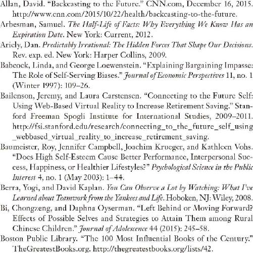

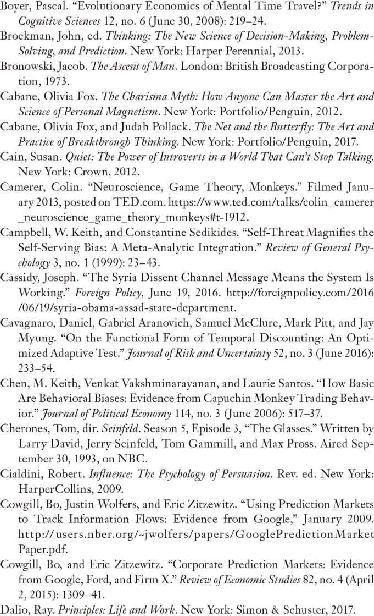

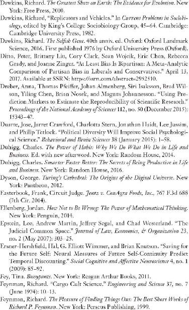

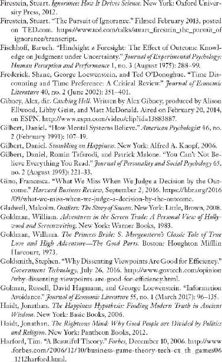

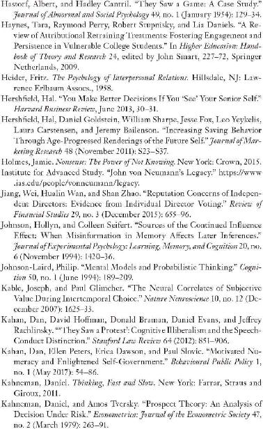

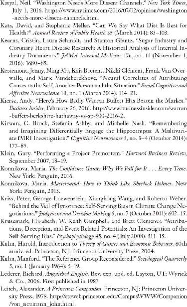

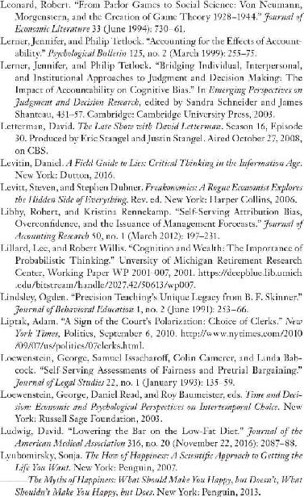

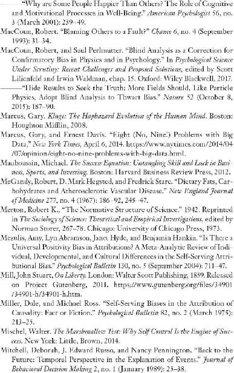

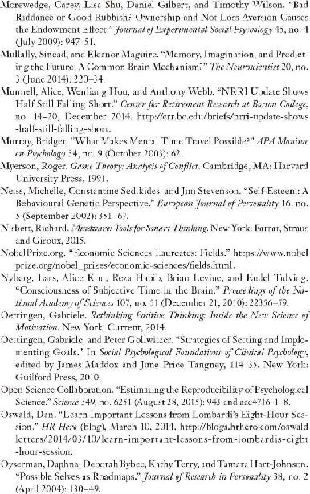

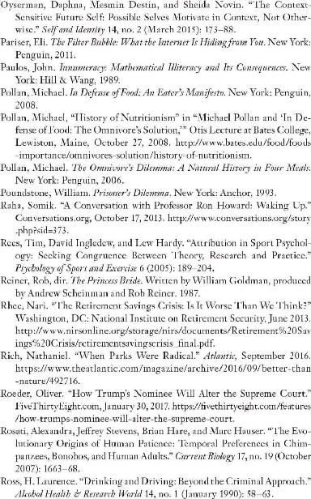

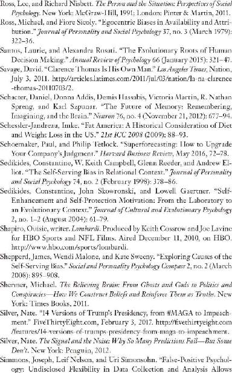

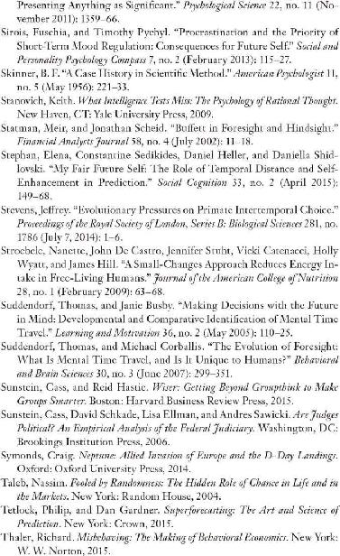

[2 more figures not shown]

**图书在版编目（CIP）数据**

对赌 : 信息不足时如何做出高明决策 / （美）安妮·杜克著 ; 李光辉译. -- 北京 : 中信出版社，2019.1

书名原文: Thinking in Bets: Making Smarter Decisions When You Don’t Have All the Facts

ISBN 978-7-5086-9649-2

Ⅰ . ①对… Ⅱ . ①安… ②李… Ⅲ . ①企业管理－管理决策 Ⅳ . ① F272.1

中国版本图书馆CIP数据核字(2018) 第231354号

THINKING IN BETS: MAKING SMARTER DECISIONS WHEN YOU DON’T HAVE ALL THE FACTS

Copyright © 2018 by Annie Duke

All rights reserved including the right of reproduction in whole or in part in any form.

This edition published by arrangement with Portfolio, an imprint of Penguin Publishing Group, a division of Penguin Random House LLC.

Simplified Chinese translation copyright © 2018 by CITIC Press Corporation

ALL RIGHTS RESERVED

**对赌 : 信息不足时如何做出高明决策**

著者：［美］安妮·杜克

译者：李光辉

出版发行：中信出版集团股份有限公司

（北京市朝阳区惠新东街甲4号富盛大厦2座 邮编100029）

字数：176千字

版次：2019年1月第1版

京权图字：01-2018-6988

广告经营许可证：京朝工商广字第8087号

书号：ISBN 978-7-5086-9649-2

**版权所有·侵权必究**